# Canoes and Seafaring

Pawley, A. and Pawley, M.

## 1. Introduction

### 1.1. Questions

Between 3000 and 1000 BC, speakers of Austronesian languages spread across Island Southeast Asia and western Melanesia and into the previously uninhabited islands of the Central Pacific.[^1] By about 1000 AD they had colonised the whole of Polynesia and Micronesia and had settled Madagascar, more than half a world away.[^2] This farflung maritime dispersal of closely related peoples, without parallel in human history until the West European expansion of the 15th-20th centuries AD, must have been based on a fairly efficient sailing technology. What was this technology? When and where did it develop? To what extent was it modified during the Austronesian diaspora?

There is already an extensive literature on these questions, much of it by culture historians who apply the typological comparative and distributional methods (discussed in §1.2) to sailing craft and sailing techniques. Our contribution will be to see what light can be thrown on these questions by comparing the vocabulary for watercraft and seafaring across the Austronesian family, using the genetic comparative method of historical linguistics. We will focus on the early phases of Austronesian expansion, that is, on cognate sets that probably go back more than 2,000 years. Little will be said here about the complex developments in boatbuilding which have taken place in Island Southeast Asia over the last couple of millenia, well after the main Austronesian dispersal across and beyond this region, or about modifications in the design of craft that according to Haddon and Hornell (Haddon 1937, Haddon & Hornell 1938, Hornell 1936) have taken place in various regions of Oceania within the last millenium. An exhaustive study of material relevant to reconstructing terms for vessel design and seafaring at all stages in the history of the Austronesian family would take several years and fill a very large book.

### 1.2. Reconstructions based on comparative typology: methodological problems

Describing the sailing craft and navigation techniques in the Indo-Pacific region, and theorising about their origins and development have been popular pastimes among Western scholars since the first European explorers visited the region.[^3] The fairly close correlation between the distribution of outrigger canoes and that of the Austronesian language family has not escaped the attention of culture historians.

Those writers who have drawn conclusions about the nature of early Austronesian sailing craft and navigation have generally relied on the ‘typological comparative method’ of historical reconstruction. The typological method is a theory of structural types, making assumptions about how structural features are linked in systems, what kinds of changes are possible or likely, which types are logically prior to others, etc. The kinds of historical inferences this method can give, when applied to a range of contemporary systems, are probabilistic ones: for example, the inference that type X is more likely to have given rise to type Y than vice versa. The typological method is often allied to a distributional one. The assumption is that one can infer much about the antiquity of a given structural type or feature from its geographic distribution. For instance, the observation that a certain complex of cultural features is found among widely scattered peoples speaking related languages can be taken as evidence that the complex was present in a common ancestral culture. On the other hand, if such a complex has a more restricted but continuous geographic distribution it is likely to have been an innovation that diffused over this region after the dispersal of the ancestral population.

In his *Sailing Craft of Indonesia* Adrian Horridge (1986:2-3) employs a distributional argument when he writes:

> The very wide distribution of their homogeneous cultural heritage shows that [the ancestral Malayo-Polynesians][^4] had an excellent knowledge of outrigger canoes for transporting fire, family, pigs, chickens and dogs, not to mention dozens of useful plants, by sea.

Other passages in the same book present some fairly detailed conclusions about the design of the vessels. These are based partly on the logic of technology—what is possible and what is likely in the development of techniques, given certain equipment and natural resources, engineering knowledge, navigational knowledge, climatic conditions, etc.—and partly on distributional grounds.

> The signs are that the original Malayo-Polynesian rig was a two-boom triangular sail fixed by the point (tack) in the bows of the boat and held up by a loose prop, with a rope to the outriggers to prevent it falling sideways. (p.56)

> All Malayo-Polynesian rigs therefore had the fundamental property that the sail could be tilted fore and aft to balance the sail with reference to the balance of the hull and load on the steering paddle. In principle they could all be steered like a windsurfer, simply by tilting the sail fore and aft. These rigs, like the outrigger canoes for which they were adapted, were invented in Island South-East Asia, and spread with the Malayo-Polynesian expansion, although they may have been known in Indonesia before that time. (p.58)

> The idea of a boat built from sewn planks was known to the Polynesian migrants into the Pacific, and perhaps came from mainland Asia before 5000 Be, but the idea of fixing the planks edge-to-edge with dowels seems to have spread later from the mainland, with the same distribution as the use of metal for boat-building tools … All the techniques needed to make a lashed-lug boat, sewn of course, were known to the earliest Polynesians, and the projecting lugs carved in situ are a feature of many traditional Polynesian, Micronesian and Melanesian boats. (pp.57-58)

In the following passage, Horridge combines structural and distributional arguments with archaeological evidence:

> The earliest evidence of trading by boats that could beat against the wind is provided by pottery with a particular design, known as Lapita, that spread rapidly from Western Melanesia far into what is now Polynesia about 3000 years ago. The vessels carrying the potters were probably double canoes because nothing else in the region is sufficiently seaworthy. (p.4)

The strength of technology-based comparative studies is in the detailed historical inferences concerning design and construction which they yield. That is not to say such inferences are necessarily reliable. There are some serious methodological weaknesses associated with all reconstructions based purely on the logic of types and the distributional method.

Because innovations in material culture sometimes spread and replace older usages and because some innovations are made independently in different places, the widespread geographic distribution of a feature or even a complex of features does not guarantee its great antiquity. Nor does the restricted distribution of a feature guarantee that it is a recent innovation. The method of comparative typology is unable to distinguish in a reliable way between ‘inherited’ and ‘borrowed’ elements or features within a continuing community or cultural tradition, that is, between institutions which have been handed down from generation to generation within the community or tradition since a given point in time, and institutions that have entered the tradition from outside since that point in time. The method is also unable to distinguish reliably between ‘retentions’ and ‘innovations’ within the same tradition, that is, between features that have been part of a tradition since a given point in time and those that were developed later.

In Indonesia and contiguous regions of Island Southeast Asia the problems of distinguishing retentions, innovations and borrowings in sailing technology are particularly acute. There, the local sailing traditions of Austronesian-speaking communities have not only diversified and influenced one another but have been exposed to numerous alien traditions coming from mainland Asia. Horridge acknowledges this point:

> The Malayo-Polynesians diversified as they spread, and from them are descended the specialized boat-building and boat-loving maritime groups of Indonesia, namely the Bajau or Sea Gypsies, the Buginese from the Gulf of Bone, the Makassarese, the Mandar people from West Sulawesi, and the Butungese from South-east Sulawesi, and the Madurese … [and] the fishennen of the islands of Bawean, Masalembu and Sepudi in the Java Sea, the traders of Bonerate and Pulau Palu’e in the Flores Sea, the whalers of Lamalerap on Lomblen in the Timor Straits, the men of Luang in the Barat Daya Islands, and the numerous Buginese colonies which control a wide network of trade in miscellaneous goods. All these very diverse groups have inherited the Malayo-Polynesian seafaring tradition, and methods of building outrigger canoes *which over the past two millenia have been mixed with traditions* *from the Indian Ocean and the West to give the modern hatch-patch of boat and canoe* *styles*. (pp.3-4) [our italics: AP & MP.]

Horridge’s remarks remind us that the testimony of central Pacific cultures is likely to be crucial in reconstructing early Austronesian sailing technology. The relative isolation of the peoples of the more remote Pacific islands may have allowed some of them to continue the early Austronesian sailing culture with fewer changes than most peoples in Island Southeast Asia.

A problem arises when students of comparative technology dabble in comparative linguistics without underpinning them by the careful studies of sound correspondences and subgroupings needed to distinguish between cognates, accidental resemblances and borrowings or to determine the relative chronology of linguistic innovations. The results of such dabblings will be largely worthless. Haddon and Hornell’s (Haddon 1937, Haddon & Hornell 1938, Hornell 1936) admirable survey, *Canoes of Oceania*, is marred by a number of fanciful historical speculations which rest in part on naive readings of linguistic similarities. To a much larger extent, however, their fanciful historical inferences rest on a diffusionist interpretation of the comparative material culture, uninformed by systematic study of comparative vocabulary or by archaeological evidence.

### 1.3. The Genetic Comparative Method

There is a means of escape from the limitations of comparative typology. It is the special virtue of the comparative or genetic method of historical linguistics that it can, in principle, (a) define genetic continuity in certain parts of the vocabulary of each language in a language family, distinguishing resemblances due to common origin from resemblances due to borrowing, and (b) assign a relative chronology to innovations occurring within the languages of a linguistic family.[^5]

However, linguists need not feel unduly smug about the genetic comparative method. It applies only to a restricted part of each language-culture system, namely the stock of morphemes that have cognates in genetically related languages. Often it happens that linguistics is silent in the face of competing hypotheses derived from comparative technology, say, about techniques of manufacture, because no distinctive terms can be reconstructed for the technological elements in question. And while the genetic method often allows us to make strong inferences about the *presence* of some things in a reconstructed language-culture system, it does not tell us what was *absent*. That is to say, our inability to reconstruct a term for a particular element in protolanguage L is not conclusive proof that speakers of L lacked a term for that element. Within these limitations, the genetic comparative method remains a powerful tool.

### 1.4. Lexical sources

Many previous publications isolate Austronesian cognate sets referring to canoe parts and seafaring. However, works compiled by linguists only list such cognate sets as isolated items within a larger body of semantically unordered material. This chapter draws together published comparisons and extends them. Sources giving relevant cognate sets or sound correspondences relevant to determining cognation include Bender et al. (1983), Biggs (1978, 1993),[^6] Blust (1970, 1972b, 1976a, 1978a, 1978b, 1980b, 1983–84a, 1986, 1989), Clark (1994), Collins (1983), Dahl (1973), Dempwolff (1938), Ferrell (1969), Geraghty (1983), Jackson (1983), Milke (1961, 1968), Pallesen (1985), Pawley (1972), Reid (1971), Ross (1988), Sneddon (1984) and Tryon (1976). We have also consulted dictionaries of many contemporary languages.

### 1.5. Organisation of reconstructions and cognate sets

Some fifty cognate sets will be discussed. These are ordered by semantic domains, such as type of vessel, beginning with types of vessels and hull construction and going on to outrigger structure, superstructure, sail and rigging, accessories, launching, beaching and anchoring and ending with terms for seafaring and seafarers.

Each reconstructed word or etymon is attributed to a certain level of the Austronesian family tree, the highest level justified by the distribution of the cognate set across subgroups. Below it are listed the cognates from contemporary languages. These are ordered according to subgroup, usually proceeding roughly in a west to east direction, e.g. Western Malayo-Polynesian cognates precede CMP cognates which in turn precede Eastern Malayo-Polynesian cognates. As well as giving the highest-level reconstruction we often give intermediate-level reconstructions for named interstages, especially when the the interstage reconstruction differs significantly in form or meaning from the highest-order reconstruction. When listing cognates we occasionally acknowledge sources when the evidence comes from Haddon (1937), Hornell (1936) or Haddon and Hornell (1938) or a source other than a published dictionary.

## 2. Types of vessel and hull construction

### 2.1. Types of vessel

Haddon and Hornell (1938: 70-72) referred to ten or so putative cognate sets having the general sense of ‘canoe’ or ‘boat’ that go back to an early stage or stages of Austronesian. While early Austronesian speakers probably had several different named types of craft, most of Haddon and Hornell’s etymologies are false. Only one of their putative cognate sets can be attributed to an early Austronesian interstage—that pointing to PCEMP *waŋka, POc *waga.

POc *waga (phonetically [wáŋga] with [ŋg] being a single phoneme) is widely reflected within Oceanic as a general term for a canoe or boat with a hull, as opposed to a raft. In many Oceanic languages, however, the reflex of *waga refers chiefly to large sailing canoes and other large vessels, in contrast to dugout canoes and small outrigger canoes. This range of meanings, taken together with the cognate set under PMP *katiR, suggests that *waga may have had two senses in POc.

| **PCEMP** |  | *waŋka | ‘outrigger canoe’ |
| --- | --- | --- | --- |
| CMP | Buru | *waga* | ‘boat, canoe’ |
| CMP | Komodo | *waŋka* | ‘boat, canoe’ |
| CMP | Manggarai | *waŋka* | ‘canoe’ |
| SHWNG | Mor | *waʔa* | ‘canoe’ |
| SHWNG | Dusner | *wak* | ‘canoe’ |
| SHWNG | Numfor | *wa(i)* | ‘outrigger canoe’ |
| SHWNG | Waropen | *wa* | ‘boat, canoe’ |
| **POc** |  | *waga | (1) ‘large sailing canoe’; (2) ‘canoe (generic)’ |
| Adm | Wuvulu | *wa* | ‘canoe’ |
| Adm | Seimat | *wa* | ‘canoe’ |
| NNG | Gedaged | *wag* | ‘large canoe that goes out on the high seas, has one or two masts and a large platform, ship or boat’ |
| NNG | Gitua | *waŋga* | ‘canoe’ |
| NNG | Yabem | *waŋ* | ‘canoe, boat, ship’ |
| PT | Dobu | *waga* | ‘sailing canoe’ |
| PT | Molima | *waga* | ‘canoe in general’ |
| PT | Kilivila | *waga* | ‘generic term for all kinds of sailing craft’ |
| PT | Wedau | *waga* | ‘large canoe’ |
| NCV | Mota | *aka* | ‘canoe’ |
| NCV | Mota | *aka (paspasau)* | ‘canoe with plank sides’ |
| NCal | Nyelâyu | *waŋga-n* | ‘his canoe’ |
| NCal | Xârâcùù | *kwā* | ‘canoe’ |
| Mic | Kiribatese | *wā* | ‘canoe’ |
| Mic | Marshallese | *wā* | ‘canoe’ |
| Mic | Puluwatese | *wā* | (1) ‘canoe, vehicle of any kind’; (2) ‘container, people in a canoe’ |
| Mic | Puluwatese | *wā(herak)* | ‘large sailing canoe able to face the high seas’ |
| Mic | Trukese | *wā* | ‘canoe, boat, vehicle’ |
| Mic | Woleaian | *wa* | ‘generic for all canoes’ |
| Fij | Bauan | *waga* | ‘generic for boats (traditionally canoes) of all kinds’ |
| Pn | Tongan | *vaka* | ‘boat (generic)’ |
| Pn | Samoan | *vaʔa* | ‘boat (generic)’ |
| Pn | Samoan | *vaʔa (folau)* | ‘sailing boat (for long voyages)’ |
| Pn | Tokelauan | *vaka* | ‘canoe, craft, boat’ |
| Pn | Tikopia | *vaka* | ‘canoe (generic)’ |
| Pn | Tikopia | *vaka (tapu)* | ‘consecrated voyaging canoe’ |
| Pn | Hawaiian | *waʔa* | ‘canoe’ |

The primary sense of POc *waga was perhaps ‘large sailing canoe’ in contrast to paddling canoes (dugouts and small outrigger canoes). This sense is widely reflected across subgroups of Oceanic. As the name of the largest and most prestigious type, *waga would have been a natural choice as a generic term for all types of canoe and in a number of languages the generic sense has become primary. An example is from Kilivila, the language of the Kiriwina people of the Trobriand Islands (reported by Haddon (1937:267-269), based on Malinowski (1922) and correspondence with Malinowski). In Kiriwina there are four named types of canoes. The *kewoʔu* is a simple dugout with outrigger, used in the lagoon. The *kalipoulo*, a fishing canoe, is a larger dugout with several designs. These have in common a hull built up with a washstrake on each side, and transverse carved and painted breakwaters, and the hull usually has pointed ends, carved and painted. There is often a platform over the booms. The sail is a lateen. The *masawa* is a large trading canoe, similarly constructed to the *kalipoulo* but with two clinker-built washstrakes on each side and twenty or more booms covered by a continuous platform. It carries a large, elongated steering oar worked by two men. The *nagega* is larger and more seaworthy than the *masawa*, with higher sides and more carrying capacity and a central standing mast, as opposed to a leaning mast stepped within the hull and shored by a prop. The generic term for all these craft is *waga*. In another part of Papua, around Samarai, Abel (1902:62) reports that *vaga* is the generic for all kinds of sailing canoes, but evidently excluded canoes without outriggers or sails.

Cognates belonging to the set above are sometimes placed together with forms listed below:

| WMP | Malay | *waŋkaŋ* | ‘Chinese junk’ |
| --- | --- | --- | --- |
| WMP | Javanese | *waŋkaŋ* | ‘Chinese junk’ |
| WMP | Ngaju Dayak | *vaŋkaŋ* | ‘Chinese junk’ |

and:

| **PAn** |  | *ba(ŋ)ka(q) | ‘outrigger canoe, dugout canoe’ |
| --- | --- | --- | --- |
| Fma | Kuvalan | *baŋka* | ‘canoe’[^7] |
| WMP | Aklanon | *baŋca* | ‘canoe’ |
| WMP | Balangaw | *baŋka* | ‘canoe’ |
| WMP | Cebuano | *baŋkaʔ* | ‘one-piece dugout between 5 and 15 metres, optionally with one or two masts and outrigger’ |
| WMP | Ilongot | *baŋka* | ‘canoe’ |
| WMP | Tagalog | *baŋkaʔ* | ‘canoe’ |
| WMP | Tausug | *baŋkaq* | ‘dugout canoe (without outrigger)’ |
| WMP | Laiyolo | *biŋka* | ‘canoe, boat’ |
| WMP | Tolaki | *baŋga* | ‘canoe’ |
| **PCEMP** |  | *ba(ŋ)ka | ‘canoe’ |
| CMP | Larike | *haka* |  |
| CMP | S. Nuaulu | *haka* |  |
| CMP | Kola | *boka* |  |
| **POc** |  | *paka | ‘ship’ |
| MM | Roviana | *vaka* |  |
| SES | Gela | *vaka* | ‘foreign vessel, European ship’ |
| SES | Sa’a | *haka* |  |

> A *manka* is a single tree trunk hollowed out, with wooden planks fastened on both sides with rattans; since they have no putty for caulking and water easily enters, the barbarians keep baling with a ladle.

It is likely (Mark Donohue, pers.comm.) that the Chinese characters in question are from the Hokkien dialect and should be read as *banka*, not *manka* as reported by Scott. The form *ba(ŋ)ka is however reflected both in CMP and Oceanic, and must be attributed to their common ancestor, which Blust (1993) labels PCEMP.

The next term is reconstructable as far back as PMP. But note the disagreement between WMP and Oceanic witnesses as to its meaning.

| **PMP** |  | *katiR | ‘(small) outrigger canoe or canoe hull’ |
| --- | --- | --- | --- |
| **PWMP** |  | *katiR | ‘outrigger float’ |
| WMP | Malay | *katir* |  |
| WMP | Madurese | *kater* |  |
| WMP | Sundanese | *katir* |  |
| WMP | Maranao | *katig* |  |
| WMP | Tausug | *katig* |  |
| WMP | Cebuano | *katig* | [N] ‘float of the outrigger’; [V] ‘provide a boat with outrigger’ |
| WMP | Sasak | *katir* | ‘carry between two persons’ |
| **POc** |  | *kati(R) | ‘(small) outrigger canoe or canoe hull’ |
| NNG | Manam | *kati* | ‘outrigger canoe’ |
| NNG | Kairiru | *qat* | ‘outrigger canoe’ |
| NNG | Tuam | *kat* | ‘canoe platform’ |
| PT | Motu | *asi* | (1) ‘hull of large multi-hulled canoe (finished more roughly than single-hulled canoe)’; (2) ‘large canoe’ |
| PT | Motu | *asi-asi* | ‘temporary small double canoe’ |
| PT | Sinaugoro | *gasi* | ‘outrigger canoe’ |
| PT | Roro | *ahi* | ‘canoe, hull’ |
| MM | Lavongai | *kati* | ‘large outrigger canoe 50 or more feet in length’ (Haddon 1937: 141) |

Although the WMP cognates denote ‘outrigger float’, there is a much stronger candidate for that meaning in PMP, namely *(c,s)a(R)man (§4.1). Therefore we conclude that *katiR is unlikely to have meant ‘outrigger float’ in PMP and that the WMP cognates probably show semantic change. In Oceanic, reflexes of *katiR are confined to Western Oceanic but are widely dispersed within that large group. The Western Oceanic comparisons strongly point to an earlier meaning such as ‘canoe hull’ or ‘small outrigger canoe’.

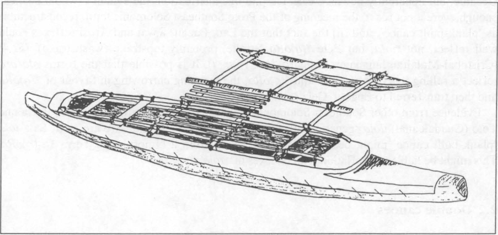

**Figure 24:** POc *waga ‘canoe’ (after Koch_n.d.: 147), POc *kati(R) ‘(small) outrigger canoe or canoe hull’, POc *(q)oRa ‘topstrake’, POc *soka(r) ‘thwart’, POc *muri- ‘stern’, POc *muqa- ‘front, bow’, POc *patar ‘platform, decking’, POc *saman ‘outrigger float’, POc *kiajo ‘outrigger boom’, POc *patoto ‘connective sticks attaching float’

If POc *kati(R) referred to a small outrigger canoe, then the following set may reflect a term for a large outrigger canoe (perhaps synonymous with *waga in its narrower sense):

| **POc** |  | *tola | ‘large canoe’ (?) |
| --- | --- | --- | --- |
| **PEAd** |  | *n-tol(V) | ‘large canoe’ |
| Adm | Titan | *drol* |  |
| Adm | Koro | *dual* |  |
| Adm | Nali | *droi* |  |
| Adm | Lele | *dol* |  |
| Adm | Ere | *drual* |  |
| Adm | Bohuai | *coal* |  |
| Adm | Mondropolon | *col* |  |
| Adm | Drehet | *kxoŋ* | ‘canoe, boat’ |
| Adm | Ponam | *hol* |  |
| Adm | Loniu | *ton* |  |
| **PSES** |  | *tola | ‘plank-built canoe’ |
| SES | Bugotu | *tola* |  |
| SES | Gela | *tola* | ‘plank-built canoe with both ends turned up not very high’ (Haddon 1937: 100) |
| SES | Lau | *ola* | ‘plank-built canoe (built up from a plank centre keel, with bow and stern keels), with no outrigger’ |
| SES | Baegu | *ola* | ‘canoe’ |
| SES | Kwai | *ola* | ‘canoe’ |
| SES | Arosi | *ora* |  |

Evidence for the reconstruction occurs in two geographically separated primary subgroups of Oceanic, but apparently nowhere else. Despite this distribution, the evidence would be clear enough, were it not for (i) the meaning of the PSES term, reconstructable as ‘plank-built canoe’, and (ii) the fact that the Lau, Baegu, Kwai and Arosi reflexes could well reflect, not *tola, but POc *(q)oRa ’strake, probably topstrake (washstrake) (§2.4) (Cristobal-Malaitan languages regularly lose POc *t). It is possible that the forms *ola*/*ora* reflect a falling together of *tola and *(q)oRa, the meaning narrowing in favour of *(q)oRa and then transferred to Bugotu, Gela *tola*.

Evidence from other Southeast Solomonic languages further confuses the issue. Gela and Tolo (Guadalcanal) *tiola* ‘generic term for plank-built canoes’ and ‘Are’are *iora*, Sa’a *iola* ’plank-built canoe’ might be explained as deriving from a bimorphemic form *ti-(q)oRa. This might be liable to conflation with reflexes of *tola also.

### 2.2. Double canoes

It has been suggested (Roger Green, pers.comm.) that the ocean-going double-hulled canoe was an innovation of Oceanic speakers. He argues that it was large double canoes, stable and able to carry big loads while being sailed with traditional rig, that were the key to the transport of people, crops and domestic animals to the far-flung islands of Remote Oceania (the Pacific islands east and north of the New Guinea area, the Bismarck Archipelago and the main Solomon Islands chain).[^8] The design of double canoes varied in some details from place to place but the main structure consisted of two dugout hulls, placed parallel and usually one to two metres apart, joined by booms, with a platform built amidships. In the most efficient craft, represented by the Fijian *drua*, one hull was slightly smaller than the other. At the time of first European contact such craft were almost wholly confined to Remote Oceania, being present in New Caledonia and Fiji, in many parts of Polynesia and in a restricted region of the central Caroline Islands. In western Melanesia double canoes were made by the Mailu, of south-east coast Papua. The Mailu speak a non-Austronesian language but many of their canoe terms (and other parts of their vocabulary) are from Austronesian; it seems likely that the population of the Mailu area was once largely Austronesian-speaking. The Motu *laɣatoi*, a multi-hulled craft, can be derived from the double canoe.

No term for double canoe can safely be reconstructed for any very early Austronesian interstage. However, a number of Oceanic languages reflect the following form:

| **PEOc** |  | *paqurua | ‘double canoe’ |
| --- | --- | --- | --- |
| SES | Lau | *foorua* | ‘outrigger canoe’ |
| Mic | Kiribatese | *baurua* | ‘large single outrigger voyaging canoe’[^9] |
| Fij | Rotuman | *foulua* | ‘ship’ (probably a Pn borrowing) |
| **PPn** |  | *faʔurua | ‘double canoe’ |
| Pn | Niuean | *faulua, foulua* | ‘ship’ |
| Pn | Rennellese | *haʔugua* | ‘the double canoe in which the ancestor *Kaituʔu* sailed when he discovered Rennell and Bellona’ |
| Pn | Tuvalu | *foulua* | [^10] |
| Pn | Māori | *hourua* |  |

cf. also:

| Fij | Bauan | *drua, waga drua* | ‘ocean-going double canoe’ |
| --- | --- | --- | --- |
| Pn | Samoan | *fau-tasi* | ‘large whaleboat’ (possibly a nineteenth century coinage) |
| Pn | Manihiki | *waka tau-rua* | ‘double canoe’ |
| Pn | Hawaiian | *waʔa kau-lua* | ‘double canoe’ (vs *waʔa kau-kasi* ‘single-hulled canoe’) |

PEOc *paqurua is a compound formed from POc *paqu(s) ‘bind, lash; construct by tying together’ (Ch. 9, § 10) and *rua ‘two’. While it is possible that Lau *foorua* is borrowed from a Polynesian language, the details of form do not support this notion. Lau has the independent bases *foo* ‘bind’ and *rua* ‘two’. Haddon (1937: 77) reports Kinilaulau (Carteret Islands) *haulau*, *holua* ‘outrigger canoe’, but this term is probably borrowed from a Polynesian language believed to have been formerly spoken on the island or from nearby Takuu.

Numerous other reconstructions, attributable to interstages lower than PMP or POc, can be made for types of craft. For example, the following doublets (distinct words coexisting in a language whose similar form and meaning suggest they ultimately trace back to the same source) can be reconstructed:

| **PWMP** |  | *padaw | ‘kind of sailboat’ (Blust 1983–84a: 90) |
| --- | --- | --- | --- |
| WMP | Maranao | *padao* | ‘sailboat’ |
| WMP | Malay | *layar padau* | ‘storm sail’ |
| WMP | Cebuano | *paraw* | ‘schooner, galleon’ |

| **PWMP** |  | *paraSu | ‘boat’ (Dempwolff 1938) |
| --- | --- | --- | --- |
| WMP | Toba Batak | *parau* |  |
| WMP | Javanese | *perau* |  |
| WMP | Malay | *perau* |  |
| WMP | Ngaju Dayak | *parau* |  |

These forms have sometimes been compared with Oceanic forms represented by Tongan *folau* ‘voyage, travel by sea’, Fijian *volau* ‘boat shed’ (cf. *pa-laSud, §9.2).

A PPn reconstruction for a small canoe used close to shore is well supported:

| **PPn** |  | *paopao | ‘small outrigger or dugout canoe for inshore use’ |
| --- | --- | --- | --- |
| Pn | Tongan | *pōpao* | ‘roughly made dugout canoe with two boom outrigger’ |
| Pn | Samoan | *paopao* | ‘small outrigger canoe with two booms’ |
| Pn | Tikopia | *paopao* | (1) ‘craft made from log simply hollowed out, not built up’; (2) ‘canoe, sea-going but not sacralised, in contrast to *vaka tapu*’ |
| Pn | Nukuoro | *paopao* | ‘double-ended single outrigger with two booms’ |

A possible cognate occurs in a single Western Oceanic language, Mekeo of the Central Province of Papua. East Mekeo has *papao* (dialect *fafao*) ‘small canoe for children, also used as a trough for feeding pigs’. Reduction of the first vowel cluster of a reduplicated word is characteristic of Mekeo (Alan Jones, pers.comm.). This comparison points to POc *paopao ‘small outrigger canoe’, though it needs strengthening by further cognates beyond Polynesian.

Blust (1986:33) reconstructs the term *dakit, noting a number of reflexes within the WMP region and a regular reflex in one Oceanic language, Motu. To these may be added many other Philippine and Northern Sulawesi reflexes (given in Reid 1971) and possible reflexes in CMP and Western Oceanic.

| **PMP** |  | *dakit | [N] ‘raft’; [V] ‘join along the length’ (Blust 1986) |
| --- | --- | --- | --- |
| WMP | Aklanon | *gākit* | ‘raft’ |
| WMP | Gaddang | *gakit* | ‘raft’ |
| WMP | Isneg | *gākit* | ‘raft’ |
| WMP | Ivatan | *dākit* | ‘raft’ |
| WMP | Kankanay | *lakit* | ‘raft’ |
| WMP | Malay | *rakit* | ‘raft’ |
| WMP | Sangir | *hakiq* | ‘raft’ |
| WMP | Sundanese | *rakit* | ‘raft’ |
| WMP | Wolio | *rakii* | [v] ‘join along the length’ |
| WMP | Balangaw | *dakit* | ‘put very close’ |
| WMP | Sika | *dakit (wii)* | ‘(earth, flour, resin) cleave, stick together’ |
| WMP | Maloh | *daʔit* | ‘raft’ |
| WMP | Maloh | *dakit* | ‘join along the length’ |
| CMP | Taliabo | *(ka)haŋkiʔ* | ‘raft’ (Charles Grimes, pers.comm.) |
| **POc** |  | *raki(t) | ‘raft; join outrigger, join two hulls’ |
| PT | Motu | *rai* | ‘prepare a canoe for the sea; tie the outrigger on; tie two canoes to make an *irai* (double-hulled canoe)’ |

Chowning (1985: 59) gives the following as possible cognates, although the final vowel is problematic:

| NNG | Kove | *laɣe* | ‘raft’ |
| --- | --- | --- | --- |
| MM | Nakanai | *lage* | ‘raft’ |

### 2.3. Hull construction

In pre-European times three basic hull designs were found in Austronesian-speaking communities: (a) a dugout built from a single log; (b) a five-part canoe, composed of dug-out hull, with the sides raised by sewing one side piece or strake to each side, with forked, crutch-shaped pieces at each end; and (c) a built-up canoe, in which a number of planks or strakes are added to a keel. The keel may consist of a thick plank or a dugout underbody (or sometimes two or even three dugouts joined).

Ethnologists have argued on logical grounds that types (b) and (c) developed from the dugout prototype. In his account of Philippine boat-building in the sixteenth and seventeenth centuries, Scott (1982: 337-338) sketches a theory of the evolution of the hull of Philippine boats:

> In the ship-building technique [developed in China and Europe in the Middle Ages] … a rigid framework of keel and ribs is first constructed … and the wooden planking of the hull then nailed to it with metal spikes or wooden trenails. The older technique was to build the hull first, plank by plank carved to fit, and to fasten the ribs in afterwards. This technique is probably a natural development of the one-log dugout canoe by adding one board to each side to obtain higher freeboard.

> By increasing the number of such additional planks, a fully developed boat or ship is produced. But as the sides of the canoe, or banca, are thinned, some transverse strengthening is required, and this can be provided by running strut-like thwarts across the vessel, securing them to the sides without nails by means of tambukos [lugs] and lashing. For this purpose a flexible rib can be pressed down across all of them and lashed securely to the matching tambukos carved on each plank. Finally a combination of such thwarts and ribs lashed together … produces a sturdy vessel whose hull and other structural parts are held firm under prestressed tension.

The question arises as to whether any or all of these features of hull design are attested in the vocabulary of PMP and other interstages.

### 2.4. Planking

The comparisons below and in §2.5 point to the use by speakers of PMP and its immediate descendants, of boats built up by planking and strengthened by thwarts:

| **PMP** |  | *papan | ‘plank (of boat +), strake’ |
| --- | --- | --- | --- |
| WMP | Malay | *papan* |  |
| WMP | Madurese | *papan* | (Horridge) |
| WMP | Bajau | *papan* | (Horridge) |
| WMP | Buginese | *papan* | (Horridge) |
| CMP | Buru | *papa-n* |  |
| **POc** |  | *baban, *bapan | (1) ‘plank’; (2) ‘canoe plank or strake’ |
| PT | Molima | *baba* | (1) ‘lower plank on canoe’; (2) ‘put plank on canoe’ |
| PT | Wedau | *papana* | ‘built-up canoe’ |
| SES | Lau | *baba* | ‘long side board of canoe’ |
| SES | Sa’a | *hapa* | (1) ‘plank’; (2) ‘thwart of canoe’ |
| SES | Bugotu | *pava* | ‘plank’ |
| Mic | Kosraean | *pæp* | ‘sides of canoe’ |
| Mic | Puluwatese | *pāp* | ‘board; canoe planks’ |
| Mic | Trukese | *pape-n (wā)* | ‘canoe strake’ (*pape-* ‘plank’, *-n* ‘construct suffix’, wā ‘canoe’) |
| Fij | Bauan | *bava* | ‘washstrake or upper planks of canoe’ |
| Fij | Bauan | *baba* | ‘side planks of canoe’ |
| Pn | Tongan | *papa* | ‘board, flat, hard surface’ |
| Pn | Hawaiian | *papa* | ‘flat, hard surface, board’ |

PMP *papan evidently referred to any plank or board (see Ch. 3, §3. S). It might be argued that this term could have been independently applied to canoe strakes or planks by different daughter languages after the break-up of PMP. However, the fact that in diverse Malayo-Polynesian languages reflexes of *papan are consistently used of canoe planks, even in cases when another general word for plank or board has developed, is a fairly strong indication that this application goes back to PMP times.

| **POc** |  | *(q)oRa | ‘strake, probably topstrake (washstrake)’ |
| --- | --- | --- | --- |
| MM | Mono-Alu | *ora* | ‘median strake at each end, above keel strakes on a canoe with dugout underbody’ |
| Pn | Niuean | *oa* | ‘washstrake, grooved and drilled for lashing to the hull’ |
| Pn | Samoan | *oa* | ‘gunwale and gunwale flange’ |
| Pn | Pukapukan | *oa* | ‘washstrake’ |
| Pn | Rarotongan | *oa* | ‘sideplank or planks of a canoe, lashed to the main body; the gunwale or seaboard of a canoe’ |
| Pn | Tokelauan | *oa* | ‘gunwale’ |
| Pn | Tikopia | *oa* | ‘top strake, gunwale’ |
| Pn | Māori | *oa* | ‘side boards of a canoe’ |

Possible cognates of *(q)oRa occur in Cristobal-Malaitan languages of the Southeast Solomonic family: Arosi *ora*, Lau *ola* ‘plank-built canoe (built up from a plank centre keel, with bow and stern keels), with no outrigger’. As noted in §2.1, however, their interpretation is difficult, as they could also reflect POc *tola ‘large canoe’.

The question of how planks were joined is connected to the question of whether early Austronesian communities used stone or metal tools, as the following remarks by Scott (1982:338-339) make clear:

> Historically there are two methods by which the planks in [Philippine] plank-built boats are fastened together—sewing and edge-pegging. Sewing—or, better said, lacing—the boards together is done by drilling a matching row of holes through the two boards near their adjoining edges, and running rattan strips through them in the manner of lacing up a shoe or basketball. This is the older technique and it can be performed with even a simple stone or bone drill, as was still being done in remote Pacific islands … Stone tools are probably inadequate for drilling deep holes in the thin edges of boards, and it is therefore not surprising that edge-pegging does not appear in those distant Pacific islands whose inhabitants presumably migrated there without metal.

We can reconstruct PMP *kiRam ‘adze/axe’ and *taRaqi (V) ‘adze, carve’ (Ch. 4, §4.1.1), with reflexes in Oceanic as well as in WMP witnesses, but there are no secure PMP or POc reconstructions for other equipment likely to have been used in boat-building.[^11] The current consensus among archaeologists is that the introduction of metal in eastern Asia postdated the break-up of PAn and PMP. Although Blust (1976b) has pointed to comparisons between Formosan and WMP forms suggesting that PAn speakers may have had a knowledge of metal tools, it is likely that this knowledge spread after the break-up of PAn and PMP.

### 2.5. Thwart, cross-seat

| **PMP** |  | *seŋkar | ‘cross-seat in boat, thwart’ (Blust 1972b) |
| --- | --- | --- | --- |
| WMP | Iban | *seŋka* |  |
| WMP | Malay | *seŋkar* |  |
| WMP | Tagalog | *saŋkal* |  |
| **POc** |  | *soka(r) | (1) ‘thwart’; (2) ‘bracing timber, crossbeam’ (cf. Ch. 3, §3.4) |
| Mic | Kiribatese | *oka* | ‘rafter of house going from horizontal beam to ridgepole’ |
| Fij | Bauan | *soka* | ‘thwart’ |
| Fij | Bauan | *(i)ðoka* | ‘collar-beam in house’ (*i-* < POc *i- INS) |
| Pn | Tongan | *hoka* | ‘upright timber supporting ridgepole’ |
| Pn | Samoan | *soʔa* | ‘collar beam of house’ |

### 2.6. Underbody, keel

There is no well-supported PMP reconstruction for ‘dugout underbody of canoe (to which planking is added)’ or for ‘keel of built-up canoe’ although *ba(ŋ)ka(q) (§2.1) is a candidate for the former. Such a term is, however, clearly reconstructable for PCP:

| **PCP** |  | *takele | ‘keel or dugout underbody to which planking is added’ |
| --- | --- | --- | --- |
| Fij | Wayan | *takele* |  |
| Fij | Bauan | *(i)takele* | (*i-* < POc *i- INS) |
| Pn | Tongan | *takele* |  |
| Pn | Samoan | *taʔele* |  |
| Pn | Tikopia | *takere* | ‘bottom of container, bilge of a canoe hull’ |
| Pn | Rarotongan | *takere* | ‘dugout underbody when washstrakes are present’ |
| Pn | Māori | *takere* |  |
| Pn | Hawaiian | *kaʔele* | ‘canoe hull; inside bottom of a container’ |

### 2.7. Bilge, interior of hull

A PPn term for ‘bilge, interior of hull’ is well supported but cognates have not been noted elsewhere. In some Polynesian languages the same term refers to the interior of any container, such as a cup or basket.

| **PPn** |  | *liu | ‘bilge, interior of hull’ |
| --- | --- | --- | --- |
| Pn | Tongan | *liu* | ‘bilge’ |
| Pn | Niuean | *liu* | ‘inside of a cup, canoe’ |
| Pn | Samoan | *liu* | ‘bilge water’ |
| Pn | Rennellese | *giu* | ‘bilge, interior of basket, bowl +’ |
| Pn | Tikopia | *riu* | ‘inside of a container; bilge of a canoe’ |
| Pn | Māori | *riu* | ‘bilge, valley, basin’ |

### 2.8. Bow and stern

Two well-attested POc locative nouns having the general sense of ‘rear, back part’, and ‘front, front part’, respectively, are reconstructable also with the specialised senses ‘stern’ and ‘bow’. The first of these terms goes back at least to PMP.

| **POc** |  | *muri- | ‘rear, stern’ |
| --- | --- | --- | --- |
| Adm | Mussau | *muri* | ‘stern’ |
| NNG | Gedaged | *muzi-n* | ‘rear, stern’ |
| MM | Nakanai | *mori* | ‘stern’ |
| MM | Vitu | *muri* | ‘stern’ |
| SES | Ghari | *muri-na* | ‘stern of a boat, hindquarters’ |
| SES | Lau | *buri* | ‘stern, rear’ |
| SES | Sa’a | *puri* | ‘stern’ |

See also PPn *tau-muri ‘afterdeck’ (§2.10)

| **POc** |  | *muqa- | ‘front, bow of boat’ |
| --- | --- | --- | --- |
| Adm | Mussau | *mua* | ‘bow’ |
| NNG | Gedaged | *muga(ŋ)* | ‘front part, bow of boat’[^12] |
| MM | Roviana | *(ke)mua* | ‘bow’ |
| Fij | Bauan | *mua* | ‘tip, point, front’ |
| Fij | Bauan | *mua (e liu)* | ‘prow of boat’ |
| Pn | Tongan | *(tau-)muʔa* | [V] ‘steer for s.t.’; [N] ‘prow’; [N] ‘aim, goal’ |
| Pn | Samoan | *(tau-)mua* | ‘bows of boats’ |

See also PPn *tau-mu ʔa ‘foredeck’ (§2.10).

### 2.9. Carved projecting end-pieces

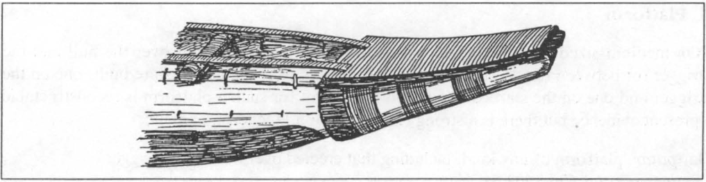

**Figure 25:** POc *ijuŋ ‘projecting headboard of prow’ (from Nevermann_1934:285)

In many regions of Oceania larger canoes are constructed with a projecting headboard, part of it resting on the underbody abutting the washstrake, the rest sometimes extending several feet beyond. The end of such headboards usually consists of an elaborately carved figurehead, often a human or animal head or figure. There is a corresponding carved end-board at the stern, often standing more or less vertical. Such carved end-pieces are common, for example, in eastern Polynesia, the Solomon Islands, the Massim, the north coast of New Guinea and the Bismarck Archipelago. A POc reconstruction can be made for the name of the headboard:

| **POc** |  | *ijuŋ | ‘projecting headboard of prow, often with ornately carved figurehead’ |
| --- | --- | --- | --- |
| Adm | Mussau | *uru(gila)* | ‘beak like projection on bow, in shape of bird’ |
| MM | New Georgia language (unspecified) (Haddon 1937: 104, 106) | *(toto)ishu* | ‘figurehead on canoe prow’ |
| SES | Sa’a | *ʔisu* | ‘pieces erected on bow and stern’ |
| SES | Lau | *isu* | ‘prow’ |
| Pn | Tikopia | *isu (fana)* | ‘pointed end of canoe’ |
| Pn | Tongareva | *isu* | ‘projecting headboard’ |
| Pn | Manihiki | *ihu* | ‘projecting headboard’ |
| Pn | Māori | *ihu (waka)* | ‘carved figurehead on prow’[^13] |
| Pn | Tahitian | *ihu, ihu (vaʔa)* | ‘projecting headboard on prow’ |
| Pn | Hawaiian | *ihu* | ‘prow’ |
| Pn | Hawaiian | *(laʔau) ihu* | ‘end-piece at head’ (vs Laʔau hope ‘end-piece at stern’) |
| **PWOc** |  | *ŋuju | ‘carved prow’ |
| PT | Iduna | *mudu* | ‘carved prow’ |
| MM | Roviana | *ŋuzu-ŋuzu* | ‘figurehead of a tomoko war canoe’ |

The central meaning of POc *ijuŋ was ‘nose’ and that of *ŋuju ‘beak, snout, mouth’. Reflexes of both commonly have the extended sense ‘projecting point’. The conjunction of Southeast Solomonic and Polynesian evidence suggests *ijuŋ as the more likely POc form carrying the sense ‘projecting headboard’. No widespread cognate set for the stempiece has been noted.

### 2.10. Bow and stern covers, end-decking

While outrigger canoes with simple dugout hull are suitable for inshore sailing, seaworthy canoes require at least ‘end-decking’, minimally a V-shaped piece covering the bow and stern of the dugout hull. The next comparison points to a PCP term for this piece; PCP *tau may come from POc *taRu ‘cover up’:

| **PCP** |  | *tau | ‘end-decking, end-piece covering bow and stern of canoe hull’ |
| --- | --- | --- | --- |
| Fij | Rotuman | *fau* | [V] ‘cover’; [N] ‘cover’ |
| Fij | Bauan | *tau* | ‘triangular decking covering bow and stern’ |
| Pn | Tongan | *tau(-muʔa)* | ‘bow, foredeck’ |
| Pn | Samoan | *tau* | ‘deck’ |
| Pn | Samoan | *tau(-mua)* | ‘bow, foredeck’ |
| Pn | Samoan | *tau(-muli)* | ‘stern, afterdeck’ |
| Pn | Nukuria | *tau* | ‘bow-board, stern-board’ |
| Pn | Tikopia | *tau(-muli)* | ‘stern’ |
| Pn | Tokelauan | *tau* | ‘point at which the keel meets the curve of the bow or stern’ |
| Pn | Tokelauan | *tau(-mua)* | ‘bow, forepart of boat’ |
| Pn | Tokelauan | *tau(-muli)* | ‘stern’ |
| Pn | Māori | *tau(-rapa)* | ‘carved end-piece affixed to stern’ |
| Pn | Māori | *tau(-ihu)* | ‘carved figurehead affixed to prow’ |

Rick Jackson (pers.comm.) suggests Proto Trukic *tau (?) ‘thwart, cross-seat in canoe’ based on Carolinian, Trukese *sō*, Puluwat *ho* ‘thwart’ . The above Polynesian comparisons also indicate PPn *tau-muʔa ‘foredeck’ and *tau-muri ‘afterdeck’.

## 3. Superstructure

### 3.1. Platform

On medium-sized and large canoes a platform is sometimes built over the hull and the outrigger (or between the two hulls on double canoes); or two platforms are built, one on the outrigger and one on the starboard side. No PMP term for such a platform is reconstructable on present evidence but there is a strong candidate for a POc term, namely:

| **PMP** |  | *pa(n)tar | ‘shelf; bed-frame of wooden or bamboo laths’ (Blust 1980b: 123) |
| --- | --- | --- | --- |
| **POc** |  | *patar | ‘platform of any kind, including that erected over hull and outrigger framework’ (cf Ch. 3, §3.5) |
| Adm | Seimat | *paca* | ‘canoe platform’ (Haddon 1937) |
| PT | Kilivila | *pita-patile* | ‘canoe platform’ |
| PT | Molima | *vata-vata* | ‘platform of any kind’ |
| PT | Molima | *vata-vatala* | ‘canoe platform’ |
| PT | Suau (Daui) | *pata-patari* | ‘canoe platform of poles stretching across all the booms’ (Haddon 1937) |
| PT | Motu | *pata* | ‘shelf, table’ |
| MM | Tolai | *vatar* | ‘bamboo or board platform on canoe’ |
| SES | Arosi | *hā* | ‘platform’ |
| SES | ’Are’are | *hā* | ‘generic name for stage, shelf, small platform above fireplace’ |
| SES | Tolo | *pata* | ‘raft’ |
| NCV | Raga | *bata* | ‘canoe platform’ (Haddon 1937) |
| Fij | Bauan | *vata* | ‘platform, shelf’ |
| Pn | Rennellese | *hata* | ‘platform, canoe platform’ |
| Pn | Samoan | *fata* | ‘platform (over canoe +)’ |

### 3.2. Cabin, deck hut

A deck hut is often added to large outrigger canoes but no widespread cognate set distinctively denoting such a structure has so far been noted. In a number of languages, reflexes of PMP *balay, POc *pale ‘hut, shed, open-sided house’ (Ch. 3, §3.3) are used for a deck hut, for example, Fijian *vale waqa* (lit. ‘canoe house’), and *valevale* ‘hut’ (Hornell 1936:323), and this may also have been the case in POc.

## 4. Outrigger structure

### 4.1. Outrigger float, outrigger side of canoe

The meaning ‘outrigger float’ can be attributed to PMP *(c,s)a(R)man. This term is well attested in Oceanic and Central/Eastern Malayo-Polynesian, but rare in WMP. In many WMP languages it has been replaced in this meaning by a reflex of *katiR (§2.1). In Oceanic languages the reflex of POc *saman also has the sense of ‘outrigger side of the canoe’ in contrast to *katae ‘free side of canoe’ (§4.4).

| **PMP** |  | *(c,s)a(R)man | ‘outrigger float’ |
| --- | --- | --- | --- |
| WMP | Sangir | *sahemaŋ* |  |
| WMP | Tonsea | *sareman* | ‘paddle’ |
| WMP | Chamorro | *sakman* | ‘large canoe from Polynesia or Papua. No outrigger, capable of carrying over 100 people’ |
| WMP | Ambonese Malay | *semaŋ* | ‘wooden strut which supports float’ |
| CMP | Buru | *seman* | ‘wooden strut which supports float’ |
| CMP | Larike | *simanu* | ‘wooden strut which supports float’ |
| CMP | Kola | *ama* | ‘wooden strut which supports float’ |
| CMP | Dobel | *yerʔman* | ‘wooden strut which supports float’ |
| CMP | Ujir (Aru Is.) | *arman* |  |
| **POc** |  | *saman | ‘outrigger float’ |
| Adm | Wuvulu | *tama-ne* |  |
| Adm | Seimat | *cam* |  |
| Adm | Mussau | *samana* |  |
| NNG | Gedaged | *sam* |  |
| NNG | Manam | *rama* | ‘outrigger’[^14] |
| MM | Nehan | *haman* | ‘boom’ (vs niag ‘float’) |
| NCV | Mota | *sama* | (1) ‘outrigger of a canoe’; (2) ‘tack, lie on the other tack’ |
| NCV | Paamese | *a-sem* | ‘outrigger’ |
| Mic | Kiribatese | *rama* |  |
| Mic | Marshallese | *tam* |  |
| Mic | Puluwatese | *tām* |  |
| Mic | Trukese | *tām* |  |
| Fij | Bauan | *ðama* | (1) ‘outrigger float’; (2) ‘smaller hull of double canoe’ |
| Pn | Tongan | *hama* | (1) ‘outrigger’; (2) ‘smaller hull of outrigger’ |
| Pn | Tikopia | *ama* | ‘outrigger including float, always on port side’ |

Oceanic languages of the Papuan Tip subgroup reflect *sarima rather than *saman (e.g. Motu *darima*, Suau (Daui) *salima*, Dobu *salime*, Molima *salima*). The *sarima forms possibly continue PMP *(c,s)a(R)man with irregular insertion of i. A similar insertion occurs in the PMP verbal prefix *paR-, continued as POc *paRi-.[^15]

### 4.2. Outrigger booms

The outrigger float is connected to the hull by booms, two or three in the case of small canoes but often five or more in larger, ocean-going canoes. A term for ‘outrigger boom’ can be constructed for POc but not for PMP:

| **POc** |  | *kiajo | ‘outrigger boom’ |
| --- | --- | --- | --- |
| Adm | Mussau | *iaro* |  |
| Adm | Loniu | *kiec* |  |
| NNG | Wogeo | *kiajo* |  |
| NNG | Manam | *kiazo* |  |
| NNG | Gedaged | *aia* |  |
| NNG | Yabem | *kion* |  |
| NNG | Barim | *kiada* |  |
| PT | Kilivila | *kiaro* |  |
| PT | Aroma | *iaro* | ‘sticks connecting floats to boom’ (Haddon 1937) |
| NCV | Nguna | *kiato* | ‘outrigger boom’ (prob. Pn borrowing) |
| Mic | Kiribatese | *kiaro* |  |
| Mic | Kosraean | *kiyɛs* |  |
| Pn | Tongan | *kiato* |  |
| Pn | Rennellese | *kiato* |  |
| Pn | Samoan | *ʔiato* |  |

Fijian *i-kaso* ‘outrigger boom’ (zero for *i irregular) has sometimes been included in this set, but probably belongs to a separate set, along with such forms as Mota *gaso* ‘rafter’, Lau *ʔato* ‘rafter’, which derive from a well-established etymon PMP *kasaw, POc *kaso ‘rafter’ (Ch. 3, §3.4). However, the comparison with Lau *ato* ‘outrigger boom’ suggests that POc *kaso probably had the general meaning ‘connecting beam or brace’, and as well as denoting crossbeams in a house may have been used as a synonym of *kiajo.

### 4.3. Connective sticks attaching float

Three main methods of connecting the outrigger float to the booms can be distinguished: direct attachment, in which all of the booms are curved and lashed directly to the outrigger; indirect attachment, in which all of the booms are lashed to sticks that are implanted in or lashed to the float; and mixed attachment, in which some booms are attached directly and others indirectly. A great diversity of methods of indirect attachment is found.

A POc reconstruction for the connective sticks (stanchions, struts) was made by Milke (1968) and is well attested. A single cognate in the north-west New Guinea language, Numfor, allows tentative attribution of this etymon (with indeterminate final vowel) to Proto Eastern Malayo-Polynesian.

| **PEMP** |  | *patotV | ‘connective sticks or stanchions attaching floats to booms’ |
| --- | --- | --- | --- |
| SHWNG | Numfor | *fakok* | (*k* for *t regular) |
| **POc** |  | *patoto | ‘connective sticks attaching float’ |
| NNG | Gedaged | *patot* |  |
| NNG | Tuam | *patot* |  |
| NNG | Mandok | *patot* |  |
| NNG | Kilenge | *patutu* |  |
| PT | Arifama | *batoto* |  |
| MM | Lihir | *hidudu* |  |
| NCV | Ambae | *batoto* |  |
| Fij | Bauan | *(i)vatoto* | (*i-* < POc: *i- INS) |

### 4.4. Starboard or hull side of outrigger canoe

A POc term can be reconstructed with the sense ’starboard or free side of the canoe, opposite the outrigger side (*saman). In Central Pacific languages this term was also applied to the larger hull of a double canoe.

| **POc** |  | *katae, *katea | ‘free side of canoe, opposite the outrigger’[^16] |
| --- | --- | --- | --- |
| NNG | Gedaged | *atai* | ‘projecting part of the canoe platform, opposite outrigger’ |
| NNG | Barim | *kat* | ‘platform of canoe’ |
| NNG | Manam | *eteʔa* | ‘port side of canoe’ |
| NNG | Tami | *kataŋ* |  |
| MM | Vitu | *kata* |  |
| NCV | Mota | *gatae* |  |
| Mic | Kiribatese | *katea* | ‘leeward side of canoe’ |
| Mic | Marshallese | *kooca* | ‘lee side of canoe’ |
| Mic | Ponapean | *(pali)kasa* | ‘lee side of canoe’ |
| Mic | Trukese | *asa* | ‘lee side of canoe’ |
| Mic | Woleaian | *(i)geta* | ‘lee side of canoe’ |
| Fij | Bauan | *katā* | (1) ‘starboard side of canoe’; (2) ‘larger hull of double canoe’ |
| Pn | Tongan | *katea* | ‘larger hull, main part of canoe as distinct from the ham’ |
| Pn | Samoan | *atea* | ‘hull side of a canoe, as opposed to the ama’ |
| Pn | Tikopia | *katea* |  |
| Pn | Hawaiian | *ʔakea* | ‘starboard hull of double canoe’ |

No non-Oceanic cognates of this set are known.

## 5. Sail and rigging

The characteristic Oceanic sail types are: (a) a triangular sprit sail with apex downwards and a spar along each of the two sides stemming from the apex, and (b) the (crab) claw sail—a triangular sail with the foreside fixed to a vertical mast and the afterside to a strongly curved sprit, whose lower end is attached to the foot of the mast. In Indonesia a number of other types of sail are found. Both fixed masts and moveable masts or props are used in Indonesia and in the Pacific Islands. The pole is stepped in a socket or on a thwart amidships and can be rotated and raked towards either end by means of running stays.

We give here a further quote from Horridge (1986:56-57):

> It is my belief, based on distribution, comparative vocabularies and engineering principles, that the fixed mast with a halyard spread into Malayo-Polynesian communities from the Indian Ocean along with the introduction of the pulley. A large sail of matting could not be raised at sea without a pulley unless it was pushed up by a loose pole. There are no signs that even the last Austronesian-speaking migrants to move out into the Pacific knew about the tripod mast, the tilted rectangular sail, the pulley or the quarter rudder lashed to a rudder support. All of these features also spread only a little way up the mainland coast towards China … The tilted rectangular sail seems to have spread from the Indian Ocean, perhaps even from … Egypt, and to have arrived in Indonesia about 2,000 years ago … It has spread eastwards about as far as the quarter rudder and the pulley.

On some of these points the linguistic evidence appears to be silent. However, several terms for parts of the rig are attributable to POc or to later interstages of Oceanic:

### 5.1. Sail

A PMP term for ‘sail’ (the object) is continued in all the major subgroups:

| **PMP** |  | *layaR | ‘sail’ |
| --- | --- | --- | --- |
| WMP | Malay | *layar* |  |
| WMP | Tagalog | *layag* |  |
| WMP | Maranao | *laiag* |  |
| WMP | Tausug | *layag* |  |
| WMP | Cebuano | *layag* | [N] ‘sail of a boat’; [V] ‘put up the sail for a boat to sail’ |
| CMP | Buru | *lā* |  |
| **POc** |  | *layaR | ‘sail’ |
| NNG | Gedaged | *lai* |  |
| NNG | Barim | *lai* |  |
| NNG | Yabem | *lac* | [N] ‘sail of a boat, a canoe’; [v] ‘sail, sail across, sail or steer a canoe towards a goal’ |
| PT | Dobu | *naia* |  |
| PT | Motu | *lara* |  |
| NCV | Namakir | *na-la* |  |
| NCV | Nguna | *na-lae* |  |
| NCV | Paamese | *alā* |  |
| Mic | Marshallese | *(wec)lay* |  |
| Fij | Bauan | *laða* |  |
| Pn | Tongan | *lā* |  |
| Pn | Samoan | *lā* |  |
| Pn | Māori | *rā* |  |

Traditional Oceanic sails are made of matting, woven from pandanus leaves or other plant fibres. It is therefore not surprising to find that reflexes of POc *qebal ‘pandanus mat’ also have the meaning ‘sail’ in a few languages. Given that POc *layaR ‘sail’ is well established, it is likely that *qebal independently acquired the sense ‘sail’ in more than one daughter language. For the cognate set, see Ch. 4, §3.1.

### 5.2. Boom and yard of sail

The following form is well attested though its reflexes show a range of meanings:

| **POc** |  | *jila | ‘boom or yard of (triangular) sail’ |
| --- | --- | --- | --- |
| Adm | Seimat | *sil* | ‘booms of triangular sail’ (Haddon 1937) |
| Adm | Penchal | *cil* | ‘sheet of sail’ |
| Adm | Lou | *(e)sil* |  |
| NNG | Tuam | *(na)sila* |  |
| NCV | Mota | *(pane) sila* |  |
| NCV | Paamese | *a-sil* | ‘mast; central trunk of tree that grows straight up’ |
| Fij | Bauan | *sila* | ‘sheet of a sail’ |
| Pn | Tongan | *sila* | [N] ‘yard, for a sail to hang from’; [V] ‘shorten the sheet of a sail’ |
| Pn | Samoan | *tila* | (1) ‘sprit or spar of sail’ (*tila lalo* ‘lower sprit’ vs *tila tu* ‘yard, upper sprit’); (2) ‘mast’ |
| Pn | Pukapukan | *tila* | ‘yard of sail’ |
| Pn | Tikopia | *tira* | ‘mast or spar of sailing canoe’ |
| Pn | Rarotongan | *tira* | ‘mast’ |
| Pn | Māori | *tira (tū)* | ‘yard of sail, upper sprit’ |

### 5.3. Mast or props supporting mast

| **PEOc** |  | *kaiu-tuqu(r) | ‘vertical supporting timber, prop supporting rig’ |
| --- | --- | --- | --- |
| SES | Arosi | *auu* | (1) ‘centre post of house’; (2) ‘mast’ |
| Mic | Carolinian | *ayu* | ‘mast’ |
| Pn | Tongan | *kau-tuʔu* | ‘yard on a mast’ |
| Pn | Samoan | *ʔau-tū* | [N] ‘core, centre, main theme’; [V] ‘centre around, revolve around s.t.’ |
| Pn | Māori | *(rā) kau-tū* | ‘mast and sail’[^17] |

cf. also:

| Adm | Seimat | *kau ehu* | ‘mast’ |
| --- | --- | --- | --- |
| PT | Motu | *au tubua* | ‘mast, centre post of a house’ (*au* ‘wood, stick’, *tubua* ‘upright’) |

POc *kaiu-tuqu(r) (evidently a compound of *kaiu ‘wood, stick, pole’ and *tuqu(r) ‘stand; fixed’) possibly referred to any main supporting timber including the prop or mast of a boat. This compound has reflexes in Southeast Solomonic, Polynesian and Nuclear Micronesian and possibly in Motu. It appears to have been already lexicalised in the immediate common ancestor of these groups.

| **PEOc** |  | *pana | ‘mast, boom stepped on foot of mast’ |
| --- | --- | --- | --- |
| NCV | Mota | *pane* | ‘boom with forked end stepped on the foot of the mast’ |
| NCV | Mota | *pane (sila)* | ‘projecting boom of a sail’ |
| Fij | Bauan | *(i)vanā* | ‘mast’ (*i-* < POc *i- INS) |
| Pn | Tongan | *fanā* | ‘mast’ |
| Pn | Samoan | *fanā* | ‘mast’ |
| Pn | Tokelauan | *fanā* | ‘mast’ |

As the Central Pacific languages in this comparison are all in the Fiji-West Polynesia region and innovations in canoe design are known to have moved freely within this region, the PCP antiquity of *vanā may be questioned. On the other hand, the correspondences Fijian *v*, Tongan, Samoan *f* are regular, unlike recent Fijian-Polynesian borrowings, where Fijian *v* has been borrowed as *v*. There is a possible cognate in Mota.

### 5.4. Mast stays

The following cognate set appears to be confined to Central Pacific:

| **PCP** |  | *tuku | ‘running stay supporting sail’ |
| --- | --- | --- | --- |
| Fij | Bauan | *tuku* |  |
| Pn | Tongan | *tuku* |  |
| Pn | Samoan | *tuʔu* | ‘running stay from foredeck’ |
| Pn | Tokelauan | *tuku* | ‘guy rope of traditional sail, fastened to the outrigger’ |

These forms may be cognate with PCP *tuku ‘let go, slacken’. Again, the narrow geographic range of this cognate set makes it hard to rule out diffusion.

## 6. Steering oar

A PMP term for steering oar is well supported. Contemporary languages which retain this term now apply it to rudders, but there is no reason to believe that rudders were in use in PMP times. A verbal use ‘steer (a boat from the stem)’ can also be reconstructed. In many languages this verbal use has now generalised to any kind of steering of a vessel or vehicle.

| **PMP** |  | *quli(n,ŋ) | [N] ‘steering oar’; [V] ‘steer’ |
| --- | --- | --- | --- |
| WMP | Cebuano | *ulin* | [N] ‘stem’; [V] ‘steer (a boat from the stem)’ |
| WMP | Maranao | *olin* | ‘steer (a vessel); manage affairs of another’ |
| WMP | Maranao | *olin(aq)* | ‘steering mechanism’ |
| WMP | Maranao | *(paŋ)olin* | ‘rudder’ |
| WMP | Bajau | *uli* | ‘steer from the stem’ |
| WMP | Sangir | *uliŋ* | [N] ‘rudder’; [v] ‘steer’ |
| WMP | Wolio | *uli* | ‘rudder’ |
| CMP | Roti | *uli* | [N] ‘rudder’; [V] ‘steer’ |
| **POc** |  | *quliŋ | [N] ‘rudder’; [V] ‘steer’ |
| Adm | Lou | *kuli(p)* | ‘steering oar’ |
| NNG | Tami | *gul* | ‘steering oar’ |
| NNG | Gedaged | *ulu(m)* | ‘rudder, steering’ |
| NNG | Yabem | *(ŋa)goliŋ* | ‘rudder’ |
| PT | Molima | *kuliga* | [N] ‘steering oar’; [V] ‘steer’ |
| PT | Kilivila | *kuliga* | ‘steering oar’ |
| Fij | Bauan | *uli* | [N] ‘steering oar, rudder, helm’; [V] ‘steer’ |
| Pn | Tongan | *ʔuli* | ‘steer’ (*fohe ʔuli* ‘rudder, steering oar’) |
| Pn | Samoan | *uli* | ‘steer’ (*faʔa -uli* ‘steer, helmsman’; *foe uli* ‘rudder’) |

## 7. Accessories

Under this heading fall objects used or carried on board, such as cargo, anchor, paddles, punting pole, bailer and Triton shell for use as a trumpet.

### 7.1. Cargo

A single base can be reconstructed, used both as a verb ‘(boat +) be loaded, carry a cargo’ and as a noun ‘cargo, load’. However, it occurs in the form of a doublet, with and without initial *l-.

| **PMP** |  | *lujan, *ujan | [V] ‘load (a vessel)’; [N] ‘load, cargo’ (Blust 1986) |
| --- | --- | --- | --- |
| WMP | Tagalog | *lulan* | ‘load, cargo, capacity of a vessel or vehicle’ |
| WMP | Makassarese | *luraŋ* | [V] ‘load’ |
| **POc** |  | *ujan, *ujan-i-, *lujan | [v] ‘load (a boat)’; [N] ‘cargo, freight’ |
| Adm | Nauna | *us* | ‘load as cargo in a boat’ |
| Adm | Seimat | *uxan-i* | ‘load as cargo in a boat’ |
| PT | Dobu | *usana* | ‘load a canoe’ |
| PT | Sinaugoro | *ɣura(udi)* | ‘load a canoe’ |
| PT | Motu | *uda-uda* | ‘load a canoe’ |
| SES | Gela | *luda* | ‘load a vessel’ |
| SES | Bugotu | *luja* | ‘load a vessel’ (*j* for *d unexplained) |
| SES | Lau | *luda* | ‘load a vessel’ |
| SES | Kwaio | *luda* | ‘load a vessel’ |
| Mic | Puluwatese | *wutan* | [v] ‘loaded’; [N] ‘cargo, load’ |
| Fij | Bauan | *usa* | ‘carry a cargo’ |
| Pn | Tongan | *uta* | [v] ‘carry a cargo’; [N] ‘cargo, freight’ |
| Pn | Samoan | *uta* | [V] ‘carry a cargo’; [N] ‘cargo, freight’ |

### 7.2. Paddles, paddling and punting

There are two well-established PMP terms to do with paddling, *be(R)(c,s)ay and *pa-luja:

| **PMP** |  | *be(R)(c,s)ay | [N] ‘(canoe) paddle’; [V] ‘paddle’ |
| --- | --- | --- | --- |
| WMP | Aklanon | *bugsay* | [N] ‘paddle’ |
| WMP | Cebuano | *bugsay* | ‘paddle or row a boat’ |
| WMP | Ngaju Dayak | *besei* | [v] ‘paddle’ |
| WMP | Buginese | *wise* | [N] ‘paddle’ |
| WMP | Wolio | *bose* | [N] ‘paddle’ |
| CMP | Taliabo | *bose* | [N] ‘paddle’ |
| CMP | Buru | *sai* | [V] ‘paddle’ |
| CMP | Buru | *sahi-n* | [N] ‘paddle’ |
| **POc** |  | *pose | [N] ‘(canoe) paddle’; [V] ‘paddle’ |
| NNG | Manam | *ore* | [N] ‘paddle’ |
| PT | Motu | *hode* | [N] ‘paddle’ |
| PT | Suau | *wose* | [N] ‘paddle’ |
| MM | Roviana | *vose* | [N] ‘paddle’ |
| SES | Gela | *vohe* | [N] ‘paddle’ |
| SES | Lau | *fote* | [N] ‘paddle’ |
| SES | Sa’a | *hote* | ‘paddle’ |
| NCV | Mota | *wose* | [N] ‘paddle’ |
| Fij | Bauan | *voðe* | [V] ‘paddle’ |
| Fij | Bauan | *(i)voðe* | [N] ‘paddle’ (*i-* < POc *i- INS) |
| Pn | Tongan | *fohe* | [N] ‘paddle’ |
| Pn | Samoan | *foe* | [N] ‘paddle’ |
| Pn | Hawaiian | *hoe* | ‘paddle’ |

| **PMP** |  | *pa-luja | [V] ‘paddle’; [N] ‘paddle’ |
| --- | --- | --- | --- |
| WMP | Nias | *aluxa* | [N] ‘paddle’ |
| WMP | Sichule | *luga* | [N] ‘paddle’ |
| WMP | Sichule | *feluxa* | [V] ‘paddle’ |
| WMP | Toba Batak | *luga* | [v] ‘row’ |
| WMP | Isneg | *piloxa* | ‘oars and paddles of a canoe’ |
| **POc** |  | *paluca | [V] ‘paddle’; [N] ‘paddle’ |
| Adm | Likum | *heluh* |  |
| MM | Roviana | *valusa* | ‘bonito fishing’ |
| SES | Arosi | *haruta* | [V] ‘paddle’ |
| SES | Lau | *falita, faluta* | [V] ‘paddle’; [N] ‘canoe’ |
| NCV | Lonwolwol | *faloh* | [V] ‘paddle’; [N] ‘paddle’ |
| NCV | Paamese | *valis, valus* | ‘row, paddle’ |
| Mic | Kiribatese | *arina* | ‘paddle’ (metathesis) |
| Mic | Mokilese | *patil* | ‘paddle’ (metathesis) |
| Mic | Ponapean | *patil* | ‘paddle’ (metathesis) |
| SV | Anejom̃ | *aheleθ* | ‘paddle’ |

It is not clear whether PMP *be(R)(c,s)ay and *paluja differed in meaning. As the Sichule comparisons show, PMP *paluja probably derives from a root *luja denoting a paddle, with the verb ‘paddle’ derived by adding the causative prefix *pa-. *paluja is now widely reflected, meaning both ‘a paddle’ and ‘to paddle’, but it may be that its use as a noun developed independently in various languages.

A third form attributable to PEOc, *sua(C), also has some reflexes glossed ‘to paddle’. However, the meanings associated with its putative reflexes are quite varied. These meanings include (i) ‘scull, in which a standing person holds the oar vertically’, (ii) ‘punt or pole a boat in shallow water’, (iii) ‘to paddle’, (iv) ‘a paddle’ and (v) ‘to steer’. The range of meanings suggests an original reference to a standing person using an oar or pole to propel or to steer a boat. (cf. also PCP *sua ‘tack’, §9.2.)

| **PEOc** |  | *sua(C) | [V] ‘scull, row with oar held vertically’ |
| --- | --- | --- | --- |
| SES | ’Are’are | *sua(hi)* | ‘paddle against the wind’ |
| SES | Lau | *sua(la)* | ‘punt, push a canoe with a pole’ |
| SES | Lau | *sua(li)* | ‘push against’ |
| NCV | Mota | *sua* | [v] ‘paddle, make a canoe voyage’ |
| NCV | Mota | *sua(va)* | [N] ‘paddling, canoe voyage’ |
| NCV | Raga | *hua* | [V] ‘paddle’ |
| NCV | Tangoa | *sua* | [V] ‘paddle’ |
| Fij | Rotuman | *sua* | ‘scull, paddle, oar’ |
| Fij | Bauan | *sua* | ‘scull, row, put an oar in two transversal poles lashed across the crossbeams near the deck of a canoe to help in rowing’ |
| Pn | Rennellese | *sua* | ‘ceremonial paddle with wide blade; go to a ship at anchor (? by paddling)’ |
| Pn | Māori | *hua* | ‘steer, paddle’ |

cf. also:

| Fij | Wayan | *due* | ‘scull, propel a boat by putting an oar or pole vertically into the water and twisting it about’ |
| --- | --- | --- | --- |
| Fij | Wayan | *i-due* | [N] ‘paddle, oar’ |
| Pn | Samoan | *sua(ti)* | ‘balance pole of canoe’ |
| Pn | Tikopia | *sua(ti)* | ‘balance pole of sailing canoe’ |
| Pn | West Uvean | *hua(ge)* | ‘balance pole of sailing canoe’ |

### 7.3. Punting pole

PMP *teken ‘pole, staff’ was evidently continued in POc both as a noun *tokon and as a transitive verb *tokon-i- (v) ‘punt or pole (a boat)’:

| **POc** |  | *tokon | ‘staff, punting pole’ |
| --- | --- | --- | --- |
| **POc** |  | *tokon-i | ‘punt or pole (a boat)’ |
| NNG | Gedaged | *tok* | ‘pole, stick, staff’ |
| NNG | Tuam | *to* | ‘punting pole’ |
| NNG | Barim | *to* | ‘punting pole’ |
| PT | Motu | *do, doa* | [V] ‘pole (a canoe)’ |
| PT | Motu | *to* | ‘stay of house, prop of fence, brace’ |
| SES | Ghari | *togon-i* | ‘stick for stirring stones’ |
| Fij | Wayan | *(i)toko* | ‘staff, punting pole’ (*i-* < POc *i- INS) |
| Fij | Wayan | *tokon-i* | ‘punt a boat’ |
| Fij | Bauan | *(i)toko* | ‘staff, punting pole’ (*i-* < POc *i- INS) |
| Fij | Bauan | *tokon(a)* | ‘punt a boat’ |
| Pn | Tongan | *toko* | ‘punting pole, to punt’ |
| Pn | Samoan | *toʔo* | ‘punting pole, to punt’ |
| Pn | Rennellese | *toko* | ‘punting pole, to punt’ |
| Pn | Tuvalu | *toko* | ‘punting pole, to punt’ |

cf. also:

| WMP | Sangir | *tekiŋ* | ‘staff’ |
| --- | --- | --- | --- |
| WMP | Malay | *teken* | ‘lean on, pressure’ |
| WMP | Javanese | *teken* | ‘cane, walking stick’ |

### 7.4. Bailer, bailing

| **PMP** |  | *limas | ‘bailer’ |
| --- | --- | --- | --- |
| WMP | Cebuano | *limas* | (1) ‘bailer’; (2) ‘bilge water’; (3) ‘bail water out’ |
| WMP | Tagalog | *limas* | ‘bailer’ |
| WMP | Hova | *dima* | ‘bailer’ |
| CMP | Boano | *limate* | ‘bailer’ |
| **POc** |  | *lima(s), *nima(s) | ‘bailer’ |
| NNG | Kilenge | *na-lima* | ‘bail’ |
| NNG | Mangseng | *lima* | ‘bail’ |
| Mic | Kiribatese | *a-nima* | ‘bailer’ |
| Mic | Puluwatese | *niim* | ‘bailer’ |
| Fij | Bauan | *(i)nima* | ‘bailer’ (*i-* < POc *i- INS) |
| Fij | Bauan | *nimat(a)* | ‘bail it out (canoe)’ |

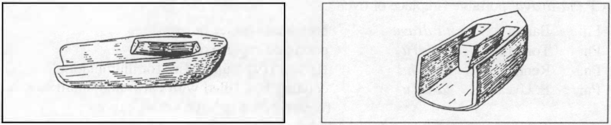

**Figure 26:** POc *lima(s) or *nima(s), POc *asu ‘bailer’

The following PMP reconstruction is given by Blust (1978b: 94). Although ‘scoop or ladle out’ was probably the basic meaning, a number of Oceanic languages use the reflex of *asu to denote a bailer.

| **PMP** |  | *aŋsu | ‘scoop or bail out’ |
| --- | --- | --- | --- |
| WMP | Javanese | *aŋsu* | ‘draw water’ |
| CMP | Buru | *asu-k* | ‘scoop, dip or bail (water) with a scooper’ |
| **POc** |  | *asu | [V] ‘scoop or ladle out’; [N] ‘ladle, bailer’ |
| Adm | Wuvulu | *atu* | ‘bailer, spoon, ladle’ |
| Adm | Aua | *atu* | ‘bailer, spoon, ladle’ |
| NNG | Gedaged | *yasi* | ‘scoop or ladle out’ |
| NCV | Nguna | *na-asu* | ‘canoe bailer’ |
| NCV | Nguna | *(m)asi* | ‘bail’ |
| NCV | Raga | *ahu(a)* | ‘bail water, scoop up’ |
| Fij | Bauan | *yaðu* | [V] ‘ladle, scoop’ |
| Pn | Tongan | *ohu* | ‘ladle or bail out liquid’ |
| Pn | Samoan | *asu* | [v] ‘scoop, ladle or bail out liquid’ |
| Pn | Māori | *ahu* | ‘bailer’ |

The next comparison shows a PPn term for ‘bailer’ and ‘bail’, derived from a PMP form which may have had a more restricted use.

| **PPn** |  | *tatā | [V] ‘bail out’; [N] ‘bailer’ |
| --- | --- | --- | --- |
| Pn | Tongan | *tatā* | ‘bail out’ |
| Pn | Samoan | *tatā* | ‘bail, scoop; anything used as a bailer’ |
| Pn | Tokelauan | *tatā* | ‘bail, scoop; anything used as a bailer’ |
| Pn | Rarotongan | *tatā* | ‘bail, scoop; anything used as a bailer’ |
| Pn | Māori | *tatā* | ‘bail, scoop; anything used as a bailer’ |

Compare WMP: Cebuano *tata* ‘empty a container by turning it upside down’. This suggests PMP *tata ‘empty water from something’.

### 7.5. Portable fireplace

Seagoing canoes in many places carry a heap of sand, or an old clay pot or wooden basin filled with sand or earth, for use as a fireplace. A reconstruction for such an apparatus can be made only at PCP level:

| **PCP** |  | *tā-dravu | ‘portable fireplace or oven’ |
| --- | --- | --- | --- |
| Fij | Bauan | *tā-dravu* | ‘portable fireplace or oven’ |
| Pn | Tongan | *tā-lafu* | ‘portable fireplace or oven’ |
| Pn | Rennellese | *tā-ŋahu* | [N] ‘fire’; [v] ‘build a fire for illumination’ |
| Pn | East Uvean | *ta-lafu* | ‘cooking box filled with earth and small stones, formerly used in large sailing canoes’ |
| Pn | Tokelauan | *tā-lefu-lefu* | ‘ashtray’ |

cf. also:

| SES | Arosi | *dohu* | ‘white ashes, a fireplace’ |
| --- | --- | --- | --- |
| NCV | Mota | *tarowo* | ‘white ashes’ |

The PCP form can be analysed into two elements: the second is clearly *dravu ‘fireplace, hearth’, which reflects POc *rapu(R) ‘hearth, fireplace; ashes’ (Ch. 6, §2.4). The origin of *tā is less clear.

## 8. Launching and beaching, anchoring, sheltering vessels

Outrigger canoes are normally launched from beaches and hauled ashore rather than anchored when not in use. Anchors are not carried on small canoes (which may be left to drift or tethered to the reef while fishing) but stone anchors were commonly carried aboard larger vessels.

### 8.1. Rollers or skids

A PMP term for canoe rollers or skids is well attested, with reflexes in Philippine, Maluku and Oceanic languages.

| **PMP** |  | *laŋen | ‘rollers, skids or blocks to move or raise a boat’ |
| --- | --- | --- | --- |
| WMP | Maranao | *laŋen* | ‘rollers’ |
| CMP | Asilulu | *lane-t* | ‘rollers’ |
| CMP | Buru | *laŋe* | ‘rollers’ |
| **POc** |  | *laŋon | [N] ‘rollers’; [V] ‘place rollers under a canoe’ |
| SES | Arosi | *(i)raŋo* | [N] ‘roller for canoe’; [V] ‘place rollers under a canoe’ (*i-* < POc *i- INS) |
| Mic | Kiribatese | *naŋo* | ‘rollers for canoe’ |
| Mic | Marshallese | *lᶭaŋ* | ‘rollers for canoe’ |
| Mic | Woleaian | *laŋo* | ‘rollers for canoe’ |
| Fij | Bauan | *laŋo* | ‘place rollers (for canoe +)’ |
| Fij | Bauan | *laŋoni ni waga* | ‘canoe rollers’ |
| Pn | Tongan | *laŋo* | ‘supporting block or beam’ |
| Pn | Samoan | *laŋo* | [N] ‘support, prop, pillow, bolster’ |
| Pn | Rennellese | *gaŋo* | ‘coaster (butt ends of coconut fronds or sticks) for dragging a canoe over the beach’ |
| Pn | Tikopia | *raŋo* | [N] ‘canoe skid or block’; [V] ‘support (canoe +)’ |

### 8.2. Anchoring

| **PMP** |  | *sauq | [N] ‘anchor’; [V] ‘be anchored’ |
| --- | --- | --- | --- |
| WMP | Tagalog | *sawoq* | ‘anchor’ |
| WMP | Toba Batak | *sawo* | ‘anchor’ |
| WMP | Malay | *sauh* | ‘anchor’ |
| WMP | Ngaju Dayak | *sauh* | ‘anchor’ |
| CMP | Buru | *sau* | ‘anchor (possibly borrowed from Malay)’ |
| SHWNG | Numfor | *sau* | ‘anchorage’ |
| **POc** |  | *jau(q) | ‘be anchored or moored, come to anchor or rest’ |
| SES | Arosi | *dau* | ‘(canoe) come to rest’ |
| SES | Lau | *dau* | ‘come to anchor; alight, be stationary, at rest’ |
| SES | Sa’a | *deu* | ‘(canoe) settle, be stationary’ |
| Pn | Tongan | *tau* | ‘anchor or moor a boat, park a car’ |
| Pn | Samoan | *tau* | ‘moor, anchor’ |
| Pn | Rennellese | *tau* | ‘come to land’ |
| Pn | Tikopia | *tau* | ‘(vessel) fetch up, come in to land’ |
| Pn | Māori | *tau* | ‘come to anchor, ride at anchor, lie to’ |

### 8.3. Passage or channel, landing place

The PMP and POc term *sawaŋ or *sawaq appears to have been the conventional name for a channel for boats to pass through or to land, or an area of calm water giving safe anchorage. Blust (1983–84a: 113) reconstructs *sawaq ‘channel’.

| **PMP** |  | *sawa(ŋ,q) | ‘opening used by boats to pass through, channel or strait, safe passage or anchorage’ |
| --- | --- | --- | --- |
| WMP | Chamorro | *sagwaʔ* | ‘channel, inlet of water, narrow passage in reef’ |
| WMP | Malay | *sawaŋ* | ‘breakwater’ |
| **POc** |  | *sawaŋ | ‘channel in reef giving passage to boats, landing place, anchorage’ |
| Adm | Lou | *(mara)sa* | ‘channel, passage between islands’ |
| Adm | Titan | *(mata)ca* | ‘channel, passage between islands’ |
| Adm | Wuvulu | *tawa* | ‘channel, passage between islands’ |
| NNG | Yabem | *sawa* | ‘space, empty area’ |
| PT | Motu | *dava* | ‘lagoon in atoll, water in chasm or ditch’ |
| MM | Roviana | *savaŋa* | ‘strait between two islands’ |
| SES | ’Are’are | *tawa* | ‘channel in reef, landing place’ |
| SES | Sa’a | *tawa* | ‘landing place’ |
| Mic | Kiribatese | *rawa* | ‘channel in reef’ |
| Mic | Marshallese | *tew* | ‘channel in reef’ |
| Mic | Ponapean | *dāw* | ‘channel in reef’ |
| Mic | Trukese | *tāw* | ‘channel in reef’ |
| Mic | Woleaian | *tāwa* | ‘channel in reef’ |
| Fij | Rotuman | *sava* | ‘passage or opening in a coral reef’ |
| Fij | Wayan | *(mata)ðawa* | ‘beach’ |
| Fij | Bauan | *(mata)sawa* | ‘landing place’ |
| Pn | Niuean | *ava* | ‘harbour, opening in reef, channel’ |
| Pn | Samoan | *ava* | ‘channel, passage in reef; anchorage’ |
| Pn | East Futunan | *ava* | ‘anchorage’ |
| Pn | Māori | *awa* | ‘channel, landing place for canoes’ |

cf. also:

| Pn | Tongan | *ava* | ‘hole, aperture’ |
| --- | --- | --- | --- |
| Pn | Tongan | *vaha* | ‘space between, strait, channel’ |

There is clear evidence for a POc compound consisting of *mata ‘opening, entrance; focal point’ plus *sawaŋ, with the sense ‘landing place for boats’. The Southeast Solomonic and Kiribatese forms suggest the POc compound had the form *mata-ni-sawaŋ, or *mata-qi-sawaŋ, with one of the two POc genitive particles *ni or *qi (Hooper 1985) linking the two nouns. However, the Admiralty Islands and Fijian forms do not reflect the genitive.

| **POc** |  | *mata-sawaŋ, *mata-[ni,qi]-sawaŋ | ‘landing place, channel in fringing reef giving passage to boats’ |
| --- | --- | --- | --- |
| Adm | Lou | *mara-sa* | ‘channel, landing place’ |
| Adm | Titan | *mata-ca* | ‘channel, landing place’ |
| SES | Arosi | *maeta-wa* | ‘boat landing, landing place where the sea is calm’ |
| SES | Kwaio | *maa-li-takwa* | ‘landing place, salt water’ (the Kwaio are an inland people) |
| SES | Sa’a | *maa-li-tawa* | ‘opening in shore reef, land place’ |
| SES | ’Are’are | *ma-ri-tawa* | ‘landing place, channel’ |
| Mic | Kiribatese | *mata n rawa-rawa* | ‘channel, gap in reef’ |
| Fij | Wayan | *mata-ðawa* | ‘beach’ |
| Fij | Bauan | *mata-sawa* | ‘landing place’ |

### 8.4. Boatshed

While boatsheds, for building and sheltering boats, are common in the Malayo-Polynesian speaking region, no really widespread cognate set for such a building has been noted outside the Central Pacific group. Some Oceanic languages use a simple term reflecting PMP *balay ‘house or building, probably with open sides’ as Lou (Admiralties) *pal* ‘boatshed’. Others use a compound nominal whose components, as in English, are the words for ‘boat’ and ‘house’ . It may be that speakers of PMP used such a compound but it is hard to rule out the possibility of independent parallel developments in the daughter languages. However, there is good evidence for a distinctive PCP term for boatshed, evidently incorporating the term for ‘make a sea voyage’ (see POc *palau(r), §9.2):

| **PCP** |  | *(a)valau | ‘boatshed’ |
| --- | --- | --- | --- |
| Fij | Wayan | *volau* | ‘boatshed’ |
| Fij | Bauan | *volau* | ‘boatshed’ |
| Pn | Tongan | *ala folau* | ‘boatshed’ (first *-l-* unexpected; cf. *ala folau* ‘fit to go to sea’) |
| Pn | Niuean | *afolau* | ‘temporary shelter’ |
| Pn | Samoan | *āfolau* | ‘long house, used for e.g. receiving guests’ |
| Pn | Tikopia | *aforau* | ‘canoe shed’ |
| Pn | Tikopia | *(mata) aforau* | ‘canoe yard for sacred canoes’ |
| Pn | Māori | *farau* | (1) ‘temporary shed or booth’; (2) ‘canoe shed’ |

## 9. Seafaring terms

A number of terms can be reconstructed at PMP or lower levels for concepts to do with going to sea and navigation. The following is not an exhaustive list.

### 9.1. Embark, ride

| **PMP** |  | *sakay | ‘embark, be aboard, ride (on a vessel +)’ |
| --- | --- | --- | --- |
| WMP | Cebuano | *sakay* | ‘travel by sea, embark, ride on (a boat +)’ |
| WMP | Ilokano | *sakay* | ‘ride in a boat’ |
| WMP | Bikol | *(mag)-sakay* | ‘ride in a boat’ |
| WMP | Sangir | *sakaeŋ* | ‘boat’ (from PMP *sakay-an lit. ‘thing to ride on’) |
| CMP | Asilulu | *saka* | ‘ascend, climb’ |
| CMP | Selaru | *sai* | ‘climb, go up, ride, mount’ |
| **POc** |  | *sake | ‘embark, ride on a canoe’ (prefix to numerals denoting number of crew carried by a canoe) |
| SES | Lau | *tae* | ‘embark’ |
| SES | ’Are’are | *taʔe* | ‘ride, embark’ (prefix in *taʔe taʔai* ‘one-man canoe’, *taʔe rua* ‘two-man canoe +’) |
| NCV | Mota | *sage* | ‘prefix with numerals when men on board a canoe are numbered’ |
| Mic | Mokilese | *tak* | ‘ride on (a vessel +)’ |
| Mic | Ponapean | *take* | ‘ride’ |
| Mic | Carolinian | *tāta* | ‘ride on s.t.’ |
| Mic | Woleaian | *tagē(a)* | ‘ride on it, sail in it’ |
| Mic | Woleaian | *(tet)tag* | ‘ride’ |
| Fij | Wayan | *ðake* | ‘embark, go aboard’ |

This was the PMP/POc term for ‘ascend, climb, mount’.

### 9.2. Voyaging

In the following set the Central Pacific forms clearly refer to long-distance sailing. There is some question whether the WMP forms are cognate with the Oceanic.

| **PMP** |  | *pa-laSud | ‘go down to the sea or coast’ |
| --- | --- | --- | --- |
| WMP | Cebuano | *palawud* | ‘go to sea’ |
| WMP | Ilokano | *palaud* | ‘go to the west, go down to the coast’ |
| WMP | Tukang Besi | *henaʔu* | ‘descend, go seawards, go west’ |
| **POc** |  | *palau(r) | ‘go to sea, make a sea voyage’ |
| SES | Tolo | *vola-volau* | ‘run, race’ |
| NCV | Raga | *walau* | ‘guide, steer, direct’ |
| NCV | Mota | *wala-walau* | ‘paddle all together’ |
| NCV | Nguna | *wo-wolau* | ‘steer canoe’ |
| Mic | Kiribatese | *borau, bo-borau* | ‘travel by sea’ (prob. borrowed from a Pn source) |
| Fij | Bauan | *volau* | [v] ‘make a sea voyage’; [N] ‘boat house’ |
| Pn | Tongan | *folau* | ‘voyage, travel by sea’ |
| Pn | Tongan | *folau(ʔaŋa)* | ‘boat in which one voyages’ (-ʔaŋa < NOM) |
| Pn | Tongan | *folau(ʔia)* | ‘be constantly visited by ships’ |
| Pn | Rennellese | *hogau* | (1) ‘ocean voyage’; (2) ‘canoe making an ocean voyage’ |
| Pn | Samoan | *folau* | ‘travel by sea, make a voyage; depart, sail’ |
| Pn | Samoan | *fōlau(ŋa)* | ‘voyage’ (-ŋa < NOM) |
| Pn | Samoan | *folau(vaʔa)* | ‘sailor’ |
| Pn | Tikopia | *forau* | ‘voyage overseas, travel abroad’ |
| Pn | Māori | *farau* | (1) ‘travel, particularly by water’; (2) ‘company of travellers’ |

cf. also:

| SES | Gela | *vinau* | ‘go by sea’ |
| --- | --- | --- | --- |
| Pn | Nukuoro | *balia* | ‘expert navigator’ |

Lawrence Reid (pers.comm.) suggests that the Malayo-Polynesian forms derive from a PAn phrase whose constituents were *pa ‘go, towards’ and *iaSud ‘sea, ocean’, giving the meaning ‘seawards (from inland)’ contrasting with *daya ‘landwards, towards the interior (from the sea or coast)’. In some languages, reflexes of *pa-laSud are opposed to a phrase or parallel structure meaning ‘go inland, go to the mountains’. POc continued *iaSud as *lau(r) in its original sense (e.g. Mota *lau* ‘seawards, coastwards’) but evidently reanalysed the sequence *pa-iau(r) as a single morpheme.

Blust (1978a:216) offers the following:

| **PEMP** |  | *ta(d,R)i | ‘steer a course (in navigating)’ |
| --- | --- | --- | --- |
| SHWNG | Numfor | *kar* | ‘row (while facing one’s destination)’ |
| **POc** |  | *taRi | ‘steer a course’ |
| PT | Motu | *tari* | [N] ‘rudder, steer oar’; [v] ‘steer a canoe’ |

The sound correspondences are regular, but one would like further cognates to strengthen the comparison. Lau *tari* ‘steer, keep straight on’ and ‘Are’are *tari*/*roro* ’steer a canoe (the steersman drawing the paddle towards himself with big strokes) show a superficial likeness but are not demonstrably cognate, because *t* in Malaitan languages derives from POc *s. Rick Jackson (pers.comm.) reconstructs Proto Western Micronesian *taraki ’sail, travel by sea’ with reflexes in Trukese, Ponapean and Marshallese but again the resemblance to PEMP *ta(d,R)i seems to be superficial.

| **PMP** |  | *biluk | ‘tack, sail to windward’ |
| --- | --- | --- | --- |
| WMP | Javanese | *biluk* | ‘tack’ |
| WMP | Malay | *belok* | ‘tack’ |
| WMP | Ngaju Dayak | *biluk* | ‘tack’ |
| WMP | Tausug | *biluk* | ‘tack’ |
| **POc** |  | *pilu(k) | ‘tack’ |
| SES | Sa’a | *hilu-hilu* | ‘zigzag’ |
| **PCP** |  | *sua | ‘tack’ |
| Fij | Rotuman | *sua* | ‘tack about, change tack’ |
| Pn | Tongan | *hua* | ‘(boat) change from one tack to another’ |

### 9.3. Expert sailor or fisherman

The following reconstruction consists of a compound with *tau ‘person, expert, owner’ as the first element and *tasi(k) ‘sea’ as the second.

| **PEOc** |  | *tau-tasik | ‘expert fisherman or sailor, mariner’ |
| --- | --- | --- | --- |
| SV | Sye | *ntoɣ* | ‘sailor’ |
| SV | Southwest Tanna | *tahik* | ‘sailor’ |
| Mic | Trukese | *sowu-set* | ‘master fisherman’ |
| Mic | Carolinian | *sou-lē-set* | ‘skilled fisherman’ |
| Pn | Tongan | *toutai* | ‘mariner, sailor; go fishing’ |
| Pn | Tongan | *toutai(ʔi)* | ‘steer or pilot (a fishing boat)’ |
| Pn | Rennellese | *tautai* | ‘go fishing in the sea’ |
| Pn | Samoan | *tautai* | ‘master fisherman, captain of a boat or ship’ |
| Pn | Tikopia | *tautai* | ‘skilled seaman, expert fisherman’ |
| Pn | Tokelauan | *tautai* | ‘master fisherman, skipper or captain of a boat’ |

cf. also:

| MM | Tolai | *te-na ta* | ‘sailor’ (lit. ‘one belonging to the sea’) |
| --- | --- | --- | --- |

### 9.4. Boat owner or captain

In the following set the first element is again *tau ‘person, owner’. The agreement between Polynesian and Papuan Tip languages may be the result of parallel development. However, in both groups the formation of compounds with *tau is no longer productive, so the chances are that the compounds in question are quite old.

| **POc** |  | *tau (ni) waga | ‘owner of a boat’ |
| --- | --- | --- | --- |
| PT | Molima | *to ni waga* | ‘canoe owner or captain’ |
| PT | Muyuw | *ta-ga-ni-wag* | ‘canoe owner or captain’ |
| Fij | Bauan | *tau-kei ni waga* | ‘boat owner’ |
| Pn | Rennellese | *tau baka* | ‘canoe owner, act as a captain’ |
| Pn | Tikopia | *tau vaka* | ‘canoe owner’ |

## 10. Conclusions

Upwards of twenty terms to do with watercraft and seafaring can be reconstructed for PMP. The comparative lexical evidence allows the following inferences. PMP speakers were familiar with outrigger sailing canoes. Various clues indicate that craft could be quite large. Hulls could be built up with planking. Skids or rollers were used to move vessels on land. A steering paddle was used. Large canoes probably carried anchors. Cargo and paddles, punting poles and bailers were carried on board.

Virtually all the reconstructable PMP canoe and seafaring terms were continued in POc and PCP. In addition, around ten terms can be attributed to POc and PCP that have not so far been reconstructed for PMP. While these figures are impressive, they probably represent only a small proportion of the total body of terms for canoes and seafaring used by the speech communities in question. In contemporary societies where large sailing canoes remain in use, it is usual for a language to have over one hundred terms for parts of the vessel alone.

Some of the POc and PCP terms which do not have known sources in PMP may be formal innovations. It seems likely, however, that in most cases the innovative forms replaced functionally equivalent PMP terms whose forms are not recoverable on present evidence. This conclusion rests on logical grounds: the presence of certain terms strongly implies that other functionally connected terms also existed. Thus, while we cannot reconstruct with certainty a PMP name for ‘outrigger sailing canoe’, we can reconstruct PMP terms for ‘outrigger float’, ‘outrigger boom’, ‘sail’ and other relevant parts and equipment. It can therefore safely be inferred that PMP speakers were familiar with outrigger sailing canoes. Furthermore, it seems that all Oceanic languages have a general name for outrigger sailing canoes (as well as, usually, a variety of terms for specific types). It would be very surprising if such a name did not exist in PMP, even if it was not cognate with the term *waŋka/*waga that has been reconstructed for PEMP and POc. The same reasoning applies, say, to ‘canoe platform’, though with slightly less force. A term for such a platform, placed amidships over hull and outrigger booms, is well supported for POc (*patar) but not for PMP. However, a PMP term for ‘load a vessel’ and ‘cargo, load carried by a vessel’ is reconstructable and it is therefore likely that PMP speakers built platforms on their larger, cargo-carrying outrigger canoes. Although a PMP term for ‘strake, plank (of canoe +)’ is recoverable, implying familiarity with built-up canoes, no term for the end-decking of a built-up canoe-minimally, triangular end-pieces abutting the topstrake fore and aft-is attributable to PMP. But as end-decking of some sort is a functional necessity in built-up seagoing outrigger canoes, it is unlikely that PMP seagoing canoes would have lacked these essential parts.

Further work will undoubtedly add to the body of relevant lexical reconstructions. However, it is unlikely to fill all the gaps. Often the lexical evidence is not fine-grained enough to allow us to recover certain details of vessel design. For example, the lexical reconstructions for the sailing rig do not indicate whether the sails used by PMP speakers were triangular, crab claw or rectangular or whether their vessels had fixed or moveable masts (or both). Nor do the lexical reconstructions tell us whether PMP speakers made canoes with single or double outriggers (or both). There is another reason why it is sometimes difficult to trace changes in technological details through comparative linguistic evidence: whereas we can safely infer knowledge of certain things by the presence of terms for them, we cannot so readily infer ignorance from the lack of reconstructable terms. Consider the double-hulled canoe. A term for double canoe can be attributed to PPn but not to POc. Can we therefore conclude that such a craft was unknown to POc speakers? Certainly not. Inability to reconstruct a term for a certain referent in Proto X does not prove that the referent itself, and a term for it, were unknown to speakers of Proto X. The term may have been lost in all or most daughter languages and its former existence obscured.

The moral we might draw at this point is a rather obvious one: that for doing culture history several disciplines are, ultimately, better than one. Linguistics and comparative technology need each other, just as both need archaeology and comparative ethnography, to corroborate each other’s evidence on certain questions and to provide testimony on points where the other disciplines are mute. It is, of course, important that each field of study contribute its own independent witness before synthesis is attempted. The challenge then becomes how to combine judiciously the evidence from different disciplines.

## Notes

[^1]: This is a slightly revised version of a paper which is included in Pawley and Ross, eds. 1994. Unlike other chapters in this volume, this chapter takes account of the Austronesian language family as a whole, rather than just of its Oceanic subgroup. We have done this because the topic of canoes and seafaring is, in an obvious way, intimately associated with the Austronesian dispersal, of which the Oceanic dispersal was simply the later part: to ignore the earlier part would be somewhat arbitrary. We are grateful to many colleagues for help. Robert Blust, Charles Grimes, Ric Jackson, Jeff Marck and Bernd Nothofer provided corrections to many points of detail as well as additional evidence. Sander Adelaar, Wal Ambrose, Mark Donohue, Paul Geraghty, Geoff Irwin, Alan Jones, Nigel Oram, Lawrence Reid and Malcolm Ross also offered valuable comments or data.
[^2]: See e.g. Shutler and Marck (1975), Bellwood (1978, 1988), Pawley and Green (1973, 1984), Spriggs (1984, 1989, 1990) for discussion of the dating of the Austronesian diaspora, using C14 dating of archaeological assemblages that can be associated with Austronesian speakers.
[^3]: Among the scores of 20th century works on these subjects are Best (1923, 1925), Doran (1981), Finney (1979), Friederici (1933), Gladwin (1970), Golson (1972), Haddon (1937), Haddon and Hornell (1938), Hornell (1936), Horridge (1978, 1981, 1986), Hutchins (1983), Irwin (1989, 1992), Lewis (1972), Sharp (1956), Siers (1977), Thomas (1987).
[^4]: Horridge recognizes the distinction that linguists now usually make between ‘Austronesian’, as the name of the entire language family, and ‘Malayo-Polynesian’, as the name for a putative subgroup that includes all Austronesian languages except those of Formosa.
[^5]: It should be stressed that the genetic comparative method is not a discovery procedure that automatically yields correct interpretations of linguistic comparisons. There are invariably ambiguities in the evidence that require choice between two or more hypotheses. The method works best when (a) the number of putative cognate sets is large, (b) the witnesses (languages compared) have had little or no contact for a long time, (c) the number of such independent witnesses in the family is large, (d) the witnesses at each level fall into more than two subgroups.
[^6]: The version of POLLEX (= Biggs 1993) used here, in fact, dates from 1990.
[^7]: Obsolete term, cited by Ferrell (1969:42, 247); the only reported cognate in a Formosan witness.
[^8]: See Pawley and Green (1973), Green (1991b) for the terms ‘Near Oceania’ and ‘Remote Oceania’.
[^9]: *b* for expected *p*, possibly borrowed from a Polynesian source.
[^10]: Obsolete (Hornell 1936:302).
[^11]: The fruit of the putty nut (*Parinari_um laurinum) is widely used to caulk or stop a vessel. In Proto Huon Gulf an identical term is reconstructable both for the nut and the glue that is made from it: Proto Huon Gulf* *jimiR_ ‘putty nut, caulking substance’ (Ross 1988:79); Tami *jim* ‘caulking substance’; Tuam *zimir* ‘caulk’; Numbami *dimil-a* ‘caulk’. The following set is of uncertain relation to *jimiR: POc *jema ‘caulk’ (Milke 1968): Motu *dema-ia* ‘caulk’; E. Fijian *sema* ‘splice, join, patch’, *sema-ta* ‘to splice, join, patch s.t.’
[^12]: Gedaged *g* for expected zero.
[^13]: Also called *tau ihu* vs *tau rapa* ‘carved ornament on stern’.
[^14]: Gloss dubious. Probably should be ‘outrigger float’.
[^15]: See Pawley (1973: 172).
[^16]: Paul Geraghty (pers.comm.) argues that the POc form was *katae, and that the form *katea is a PPn innovation which has been borrowed by a few other languages.
[^17]: According to Best (1925: 183), the term *ra kautu* [=*raa kautuu*] refers to a (triangular) sail with mast that is stepped upright in a cupped boss on the floor of the dugout.